# ФС Промышленность

**Цель проекта**

**Оптимизация производственных расходов металлургического комбината. Модель позволит снизить затраты на электричество, обслуживание и ремонты.**

## Исследовательский анализ данных

### Используемые библиотеки

```python
import pandas as pd
import numpy as np
import matplotlib.pyplot as plt
import seaborn as sns
import os
import os.path as pth
import lightgbm as lgb
from scipy import stats as st
import catboost as cb
import warnings
warnings.filterwarnings('ignore')
warnings.filterwarnings("ignore", category=DeprecationWarning)
warnings.filterwarnings("ignore", category=UserWarning)

from sklearn.model_selection import train_test_split
from sklearn.model_selection import RandomizedSearchCV
from sklearn.model_selection import cross_val_score
from sklearn.model_selection import RepeatedKFold
from sklearn.model_selection import GridSearchCV
from sklearn.model_selection import RepeatedStratifiedKFold

from sklearn.metrics import make_scorer
from sklearn.metrics import mean_absolute_error
from sklearn.metrics import mean_squared_error, r2_score, median_absolute_error
from sklearn.metrics import precision_recall_curve
from sklearn.metrics import accuracy_score
from sklearn.metrics import roc_auc_score
from sklearn.metrics import f1_score

from sklearn.tree import DecisionTreeRegressor
from sklearn.ensemble import RandomForestRegressor
from sklearn.ensemble import IsolationForest
from sklearn.linear_model import LinearRegression
from sklearn.utils import shuffle
from sklearn.preprocessing import StandardScaler
from scipy.stats import randint
from sklearn.dummy import DummyRegressor
from sklearn.datasets import make_regression

from lightgbm import LGBMRegressor
np.set_printoptions(precision=4)

from catboost import *
from catboost import datasets
from catboost import CatBoostRegressor
from catboost import Pool, cv
```

### Загрузка данных

```python
# Зададим путь к файлам в зависимости от места загрузки
if pth.exists('/datasets'):
    path = '/datasets/'
else:
    path = ''
```

```python
# Загрузим данные и ознакомимся с их содержанием

any_file = ['data_arc_new.csv', 'data_bulk_new.csv', 'data_bulk_time_new.csv',
            'data_gas_new.csv', 'data_temp_new.csv', 'data_wire_new.csv', 'data_wire_time_new.csv']
name = ['arc', 'bulk', 'bulk_time', 'gas', 'temp', 'wire', 'wire_time']
data = ['arc', 'bulk', 'bulk_time', 'gas', 'temp', 'wire', 'wire_time']

for i in range(len(name)):
    data[i] = pd.read_csv(path + any_file[i], sep=',') #
    data[i]['key'] = data[i]['key'].astype('uint16')# Изменяем тип данных int64 -> uint16
    print(name[i])
    display(data[i].head(5))
```

```
arc
```

|  | key | Начало нагрева дугой | Конец нагрева дугой | Активная мощность | Реактивная мощность |
| --- | --- | --- | --- | --- | --- |
| 0 | 1 | 2019-05-03 11:02:14 | 2019-05-03 11:06:02 | 0.305130 | 0.211253 |
| 1 | 1 | 2019-05-03 11:07:28 | 2019-05-03 11:10:33 | 0.765658 | 0.477438 |
| 2 | 1 | 2019-05-03 11:11:44 | 2019-05-03 11:14:36 | 0.580313 | 0.430460 |
| 3 | 1 | 2019-05-03 11:18:14 | 2019-05-03 11:24:19 | 0.518496 | 0.379979 |
| 4 | 1 | 2019-05-03 11:26:09 | 2019-05-03 11:28:37 | 0.867133 | 0.643691 |

```
bulk
```

|  | key | Bulk 1 | Bulk 2 | Bulk 3 | Bulk 4 | Bulk 5 | Bulk 6 | Bulk 7 | Bulk 8 | Bulk 9 | Bulk 10 | Bulk 11 | Bulk 12 | Bulk 13 | Bulk 14 | Bulk 15 |
| --- | --- | --- | --- | --- | --- | --- | --- | --- | --- | --- | --- | --- | --- | --- | --- | --- |
| 0 | 1 | NaN | NaN | NaN | 43.0 | NaN | NaN | NaN | NaN | NaN | NaN | NaN | 206.0 | NaN | 150.0 | 154.0 |
| 1 | 2 | NaN | NaN | NaN | 73.0 | NaN | NaN | NaN | NaN | NaN | NaN | NaN | 206.0 | NaN | 149.0 | 154.0 |
| 2 | 3 | NaN | NaN | NaN | 34.0 | NaN | NaN | NaN | NaN | NaN | NaN | NaN | 205.0 | NaN | 152.0 | 153.0 |
| 3 | 4 | NaN | NaN | NaN | 81.0 | NaN | NaN | NaN | NaN | NaN | NaN | NaN | 207.0 | NaN | 153.0 | 154.0 |
| 4 | 5 | NaN | NaN | NaN | 78.0 | NaN | NaN | NaN | NaN | NaN | NaN | NaN | 203.0 | NaN | 151.0 | 152.0 |

```
bulk_time
```

|  | key | Bulk 1 | Bulk 2 | Bulk 3 | Bulk 4 | Bulk 5 | Bulk 6 | Bulk 7 | Bulk 8 | Bulk 9 | Bulk 10 | Bulk 11 | Bulk 12 | Bulk 13 | Bulk 14 | Bulk 15 |
| --- | --- | --- | --- | --- | --- | --- | --- | --- | --- | --- | --- | --- | --- | --- | --- | --- |
| 0 | 1 | NaN | NaN | NaN | 2019-05-03 11:28:48 | NaN | NaN | NaN | NaN | NaN | NaN | NaN | 2019-05-03 11:24:31 | NaN | 2019-05-03 11:14:50 | 2019-05-03 11:10:43 |
| 1 | 2 | NaN | NaN | NaN | 2019-05-03 11:36:50 | NaN | NaN | NaN | NaN | NaN | NaN | NaN | 2019-05-03 11:53:30 | NaN | 2019-05-03 11:48:37 | 2019-05-03 11:44:39 |
| 2 | 3 | NaN | NaN | NaN | 2019-05-03 12:32:39 | NaN | NaN | NaN | NaN | NaN | NaN | NaN | 2019-05-03 12:27:13 | NaN | 2019-05-03 12:21:01 | 2019-05-03 12:16:16 |
| 3 | 4 | NaN | NaN | NaN | 2019-05-03 12:43:22 | NaN | NaN | NaN | NaN | NaN | NaN | NaN | 2019-05-03 12:58:00 | NaN | 2019-05-03 12:51:11 | 2019-05-03 12:46:36 |
| 4 | 5 | NaN | NaN | NaN | 2019-05-03 13:30:47 | NaN | NaN | NaN | NaN | NaN | NaN | NaN | 2019-05-03 13:30:47 | NaN | 2019-05-03 13:34:12 | 2019-05-03 13:30:47 |

```
gas
```

|  | key | Газ 1 |
| --- | --- | --- |
| 0 | 1 | 29.749986 |
| 1 | 2 | 12.555561 |
| 2 | 3 | 28.554793 |
| 3 | 4 | 18.841219 |
| 4 | 5 | 5.413692 |

```
temp
```

|  | key | Время замера | Температура |
| --- | --- | --- | --- |
| 0 | 1 | 2019-05-03 11:02:04 | 1571.0 |
| 1 | 1 | 2019-05-03 11:07:18 | 1604.0 |
| 2 | 1 | 2019-05-03 11:11:34 | 1618.0 |
| 3 | 1 | 2019-05-03 11:18:04 | 1601.0 |
| 4 | 1 | 2019-05-03 11:25:59 | 1606.0 |

```
wire
```

|  | key | Wire 1 | Wire 2 | Wire 3 | Wire 4 | Wire 5 | Wire 6 | Wire 7 | Wire 8 | Wire 9 |
| --- | --- | --- | --- | --- | --- | --- | --- | --- | --- | --- |
| 0 | 1 | 60.059998 | NaN | NaN | NaN | NaN | NaN | NaN | NaN | NaN |
| 1 | 2 | 96.052315 | NaN | NaN | NaN | NaN | NaN | NaN | NaN | NaN |
| 2 | 3 | 91.160157 | NaN | NaN | NaN | NaN | NaN | NaN | NaN | NaN |
| 3 | 4 | 89.063515 | NaN | NaN | NaN | NaN | NaN | NaN | NaN | NaN |
| 4 | 5 | 89.238236 | 9.11456 | NaN | NaN | NaN | NaN | NaN | NaN | NaN |

```
wire_time
```

|  | key | Wire 1 | Wire 2 | Wire 3 | Wire 4 | Wire 5 | Wire 6 | Wire 7 | Wire 8 | Wire 9 |
| --- | --- | --- | --- | --- | --- | --- | --- | --- | --- | --- |
| 0 | 1 | 2019-05-03 11:06:19 | NaN | NaN | NaN | NaN | NaN | NaN | NaN | NaN |
| 1 | 2 | 2019-05-03 11:36:50 | NaN | NaN | NaN | NaN | NaN | NaN | NaN | NaN |
| 2 | 3 | 2019-05-03 12:11:46 | NaN | NaN | NaN | NaN | NaN | NaN | NaN | NaN |
| 3 | 4 | 2019-05-03 12:43:22 | NaN | NaN | NaN | NaN | NaN | NaN | NaN | NaN |
| 4 | 5 | 2019-05-03 13:20:44 | 2019-05-03 13:15:34 | NaN | NaN | NaN | NaN | NaN | NaN | NaN |

### Обзор данных

```python
# Общая информация о данных
for i in range(len(data)):
    print(name[i])
    display(data[i].info())
```

```
arc
<class 'pandas.core.frame.DataFrame'>
RangeIndex: 14876 entries, 0 to 14875
Data columns (total 5 columns):
 #   Column                Non-Null Count  Dtype
---  ------                --------------  -----
 0   key                   14876 non-null  uint16
 1   Начало нагрева дугой  14876 non-null  object
 2   Конец нагрева дугой   14876 non-null  object
 3   Активная мощность     14876 non-null  float64
 4   Реактивная мощность   14876 non-null  float64
dtypes: float64(2), object(2), uint16(1)
memory usage: 494.1+ KB
```

```
None
```

```
bulk
<class 'pandas.core.frame.DataFrame'>
RangeIndex: 3129 entries, 0 to 3128
Data columns (total 16 columns):
 #   Column   Non-Null Count  Dtype
---  ------   --------------  -----
 0   key      3129 non-null   uint16
 1   Bulk 1   252 non-null    float64
 2   Bulk 2   22 non-null     float64
 3   Bulk 3   1298 non-null   float64
 4   Bulk 4   1014 non-null   float64
 5   Bulk 5   77 non-null     float64
 6   Bulk 6   576 non-null    float64
 7   Bulk 7   25 non-null     float64
 8   Bulk 8   1 non-null      float64
 9   Bulk 9   19 non-null     float64
 10  Bulk 10  176 non-null    float64
 11  Bulk 11  177 non-null    float64
 12  Bulk 12  2450 non-null   float64
 13  Bulk 13  18 non-null     float64
 14  Bulk 14  2806 non-null   float64
 15  Bulk 15  2248 non-null   float64
dtypes: float64(15), uint16(1)
memory usage: 372.9 KB
```

```
None
```

```
bulk_time
<class 'pandas.core.frame.DataFrame'>
RangeIndex: 3129 entries, 0 to 3128
Data columns (total 16 columns):
 #   Column   Non-Null Count  Dtype
---  ------   --------------  -----
 0   key      3129 non-null   uint16
 1   Bulk 1   252 non-null    object
 2   Bulk 2   22 non-null     object
 3   Bulk 3   1298 non-null   object
 4   Bulk 4   1014 non-null   object
 5   Bulk 5   77 non-null     object
 6   Bulk 6   576 non-null    object
 7   Bulk 7   25 non-null     object
 8   Bulk 8   1 non-null      object
 9   Bulk 9   19 non-null     object
 10  Bulk 10  176 non-null    object
 11  Bulk 11  177 non-null    object
 12  Bulk 12  2450 non-null   object
 13  Bulk 13  18 non-null     object
 14  Bulk 14  2806 non-null   object
 15  Bulk 15  2248 non-null   object
dtypes: object(15), uint16(1)
memory usage: 372.9+ KB
```

```
None
```

```
gas
<class 'pandas.core.frame.DataFrame'>
RangeIndex: 3239 entries, 0 to 3238
Data columns (total 2 columns):
 #   Column  Non-Null Count  Dtype
---  ------  --------------  -----
 0   key     3239 non-null   uint16
 1   Газ 1   3239 non-null   float64
dtypes: float64(1), uint16(1)
memory usage: 31.8 KB
```

```
None
```

```
temp
<class 'pandas.core.frame.DataFrame'>
RangeIndex: 18092 entries, 0 to 18091
Data columns (total 3 columns):
 #   Column        Non-Null Count  Dtype
---  ------        --------------  -----
 0   key           18092 non-null  uint16
 1   Время замера  18092 non-null  object
 2   Температура   14665 non-null  float64
dtypes: float64(1), object(1), uint16(1)
memory usage: 318.2+ KB
```

```
None
```

```
wire
<class 'pandas.core.frame.DataFrame'>
RangeIndex: 3081 entries, 0 to 3080
Data columns (total 10 columns):
 #   Column  Non-Null Count  Dtype
---  ------  --------------  -----
 0   key     3081 non-null   uint16
 1   Wire 1  3055 non-null   float64
 2   Wire 2  1079 non-null   float64
 3   Wire 3  63 non-null     float64
 4   Wire 4  14 non-null     float64
 5   Wire 5  1 non-null      float64
 6   Wire 6  73 non-null     float64
 7   Wire 7  11 non-null     float64
 8   Wire 8  19 non-null     float64
 9   Wire 9  29 non-null     float64
dtypes: float64(9), uint16(1)
memory usage: 222.8 KB
```

```
None
```

```
wire_time
<class 'pandas.core.frame.DataFrame'>
RangeIndex: 3081 entries, 0 to 3080
Data columns (total 10 columns):
 #   Column  Non-Null Count  Dtype
---  ------  --------------  -----
 0   key     3081 non-null   uint16
 1   Wire 1  3055 non-null   object
 2   Wire 2  1079 non-null   object
 3   Wire 3  63 non-null     object
 4   Wire 4  14 non-null     object
 5   Wire 5  1 non-null      object
 6   Wire 6  73 non-null     object
 7   Wire 7  11 non-null     object
 8   Wire 8  19 non-null     object
 9   Wire 9  29 non-null     object
dtypes: object(9), uint16(1)
memory usage: 222.8+ KB
```

```
None
```

Вывод:

-для последующего анализа необходимо преобразовать даты в соответствующий им формат,

-для экономии вычислительных ресурсов минимизируем числовые форматы,

### Поготовка данных

#### Удаление явных дубликатов во всех датасетах

```python
for i in range(len(data)):
    print(name[i])
    print(data[i].duplicated().sum())
    data[i] = data[i].drop_duplicates(keep='first')#  Удаляем явные дубликаты, если они есть,
    # оставляя первые значения
```

```
arc
0
bulk
0
bulk_time
0
gas
0
temp
0
wire
0
wire_time
0
```

Вывод: Дубликатов нет

#### `arc` (data[0]) Циклы нагрева. Мощность.

```python
data[0]['Начало нагрева дугой'] = pd.to_datetime(data[0]['Начало нагрева дугой'], format='%Y-%m-%d %H:%M:%S')
data[0]['Конец нагрева дугой'] = pd.to_datetime(data[0]['Конец нагрева дугой'], format='%Y-%m-%d %H:%M:%S')
data[0]['Активная мощность'] = data[0]['Активная мощность'].astype('float32')# Изменение float64 -> float32
data[0]['Реактивная мощность'] = data[0]['Реактивная мощность'].astype('float32')# Изменение float64 -> float32
```

Вывод:

-Строка данных состоит из номера партии, двух дат образующих интервал и значений `Активной` и `Реактивной мощностей`.

-Работа (нагревание расплава) пропорциональна интегралу `Активной мощности` (мгновенной) по интервалу времени.

-Сделаем допущение, что данные содержат значения средней за цикл, а не мгновенной мощности. В противном случае они малоинформативны. Это будет первый уточняющий вопрос. В соответствии с допущением о средней мощности сформируем три новых столбца.

```python
# Добавляем 3 столбца
data[0]['t_н, с'] = (data[0]['Конец нагрева дугой'] -
                     data[0]['Начало нагрева дугой']).dt.total_seconds().astype('uint16')# Время нагрева в секундах
data[0]['E_a'] = data[0]['Активная мощность'] * data[0]['t_н, с']#.astype('float32')# Энергия нагрева активная
data[0]['E_p'] = data[0]['Реактивная мощность'] * data[0]['t_н, с']#.astype('float32')# Энергия  реактивная
# потраченная при нагреве
data[0].info()
print(name[0])
data[0]
```

```
<class 'pandas.core.frame.DataFrame'>
Int64Index: 14876 entries, 0 to 14875
Data columns (total 8 columns):
 #   Column                Non-Null Count  Dtype
---  ------                --------------  -----
 0   key                   14876 non-null  uint16
 1   Начало нагрева дугой  14876 non-null  datetime64[ns]
 2   Конец нагрева дугой   14876 non-null  datetime64[ns]
 3   Активная мощность     14876 non-null  float32
 4   Реактивная мощность   14876 non-null  float32
 5   t_н, с                14876 non-null  uint16
 6   E_a                   14876 non-null  float32
 7   E_p                   14876 non-null  float32
dtypes: datetime64[ns](2), float32(4), uint16(2)
memory usage: 639.2 KB
arc
```

|  | key | Начало нагрева дугой | Конец нагрева дугой | Активная мощность | Реактивная мощность | t_н, с | E_a | E_p |
| --- | --- | --- | --- | --- | --- | --- | --- | --- |
| 0 | 1 | 2019-05-03 11:02:14 | 2019-05-03 11:06:02 | 0.305130 | 0.211253 | 228 | 69.569641 | 48.165684 |
| 1 | 1 | 2019-05-03 11:07:28 | 2019-05-03 11:10:33 | 0.765658 | 0.477438 | 185 | 141.646729 | 88.326027 |
| 2 | 1 | 2019-05-03 11:11:44 | 2019-05-03 11:14:36 | 0.580313 | 0.430460 | 172 | 99.813843 | 74.039124 |
| 3 | 1 | 2019-05-03 11:18:14 | 2019-05-03 11:24:19 | 0.518496 | 0.379979 | 365 | 189.251038 | 138.692337 |
| 4 | 1 | 2019-05-03 11:26:09 | 2019-05-03 11:28:37 | 0.867133 | 0.643691 | 148 | 128.335693 | 95.266266 |
| ... | ... | ... | ... | ... | ... | ... | ... | ... |
| 14871 | 3241 | 2019-09-06 16:49:05 | 2019-09-06 16:51:42 | 0.439735 | 0.299579 | 157 | 69.038391 | 47.033901 |
| 14872 | 3241 | 2019-09-06 16:55:11 | 2019-09-06 16:58:11 | 0.646498 | 0.458240 | 180 | 116.369644 | 82.483200 |
| 14873 | 3241 | 2019-09-06 17:06:48 | 2019-09-06 17:09:52 | 1.039726 | 0.769302 | 184 | 191.309586 | 141.551575 |
| 14874 | 3241 | 2019-09-06 17:21:58 | 2019-09-06 17:22:55 | 0.530267 | 0.361543 | 57 | 30.225220 | 20.607950 |
| 14875 | 3241 | 2019-09-06 17:24:54 | 2019-09-06 17:26:15 | 0.389057 | 0.251347 | 81 | 31.513618 | 20.359108 |

14876 rows × 8 columns

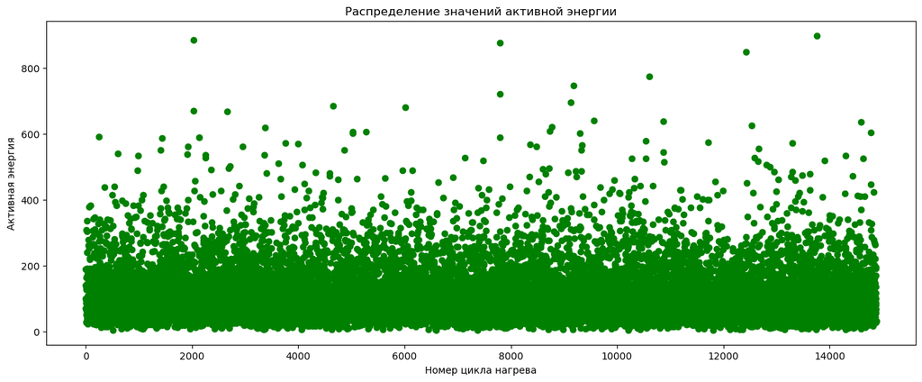

```python
x = data[0].index.tolist() #  x - координаты точек
y = data[0]['E_a']#  y - координаты точек

fig, ax = plt.subplots()
ax.scatter(x, y, c = 'g')    #  цвет точек
ax.set_facecolor('w')     #  цвет области
ax.set_title('Распределение значений активной энергии')     #  заголовок
plt.xlabel("Номер цикла нагрева")
plt.ylabel("Активная энергия")
fig.set_figwidth(16)     #  ширина и
fig.set_figheight(6)    #  высота

plt.show()
```

```python
data[0]['E_a'].describe()
```

```
count    14876.000000
mean       114.044273
std         83.005898
min          5.246505
25%         57.376903
50%         92.194118
75%        145.983543
max        898.200867
Name: E_a, dtype: float64
```

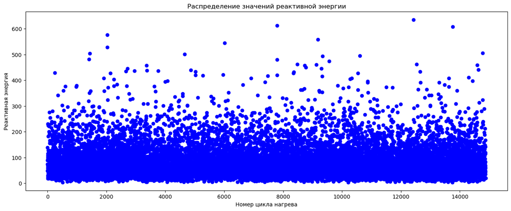

```python
d = data[0][data[0]['E_p'] > 0]# Исключаем одну строку с отридцательной энергией
x = d.index.tolist() #  x - координаты точек
y = d['E_p']#  y - координаты точек

fig, ax = plt.subplots()
ax.scatter(x, y, c = 'b')    #  цвет точек
ax.set_facecolor('w')     #  цвет области
ax.set_title('Распределение значений реактивной энергии')     #  заголовок
plt.xlabel("Номер цикла нагрева")
plt.ylabel("Реактивная энергия")
fig.set_figwidth(16)     #  ширина и
fig.set_figheight(6)    #  высота

plt.show()
```

Вывод:

-Количество циклов нагрева в партиях разное.

-Единственное значение реактивной энергии меньше 0 - выброс.

-Необходимо уточнить допущенное предположение, что данные содержат значения средней за цикл, а не мгновенной мощности.

#### `bulk` (data[1]) Сыпучие добавки. Масса.

```python
print(name[1])
print(data[1].info())
data[1]
```

```
bulk
<class 'pandas.core.frame.DataFrame'>
Int64Index: 3129 entries, 0 to 3128
Data columns (total 16 columns):
 #   Column   Non-Null Count  Dtype
---  ------   --------------  -----
 0   key      3129 non-null   uint16
 1   Bulk 1   252 non-null    float64
 2   Bulk 2   22 non-null     float64
 3   Bulk 3   1298 non-null   float64
 4   Bulk 4   1014 non-null   float64
 5   Bulk 5   77 non-null     float64
 6   Bulk 6   576 non-null    float64
 7   Bulk 7   25 non-null     float64
 8   Bulk 8   1 non-null      float64
 9   Bulk 9   19 non-null     float64
 10  Bulk 10  176 non-null    float64
 11  Bulk 11  177 non-null    float64
 12  Bulk 12  2450 non-null   float64
 13  Bulk 13  18 non-null     float64
 14  Bulk 14  2806 non-null   float64
 15  Bulk 15  2248 non-null   float64
dtypes: float64(15), uint16(1)
memory usage: 397.2 KB
None
```

|  | key | Bulk 1 | Bulk 2 | Bulk 3 | Bulk 4 | Bulk 5 | Bulk 6 | Bulk 7 | Bulk 8 | Bulk 9 | Bulk 10 | Bulk 11 | Bulk 12 | Bulk 13 | Bulk 14 | Bulk 15 |
| --- | --- | --- | --- | --- | --- | --- | --- | --- | --- | --- | --- | --- | --- | --- | --- | --- |
| 0 | 1 | NaN | NaN | NaN | 43.0 | NaN | NaN | NaN | NaN | NaN | NaN | NaN | 206.0 | NaN | 150.0 | 154.0 |
| 1 | 2 | NaN | NaN | NaN | 73.0 | NaN | NaN | NaN | NaN | NaN | NaN | NaN | 206.0 | NaN | 149.0 | 154.0 |
| 2 | 3 | NaN | NaN | NaN | 34.0 | NaN | NaN | NaN | NaN | NaN | NaN | NaN | 205.0 | NaN | 152.0 | 153.0 |
| 3 | 4 | NaN | NaN | NaN | 81.0 | NaN | NaN | NaN | NaN | NaN | NaN | NaN | 207.0 | NaN | 153.0 | 154.0 |
| 4 | 5 | NaN | NaN | NaN | 78.0 | NaN | NaN | NaN | NaN | NaN | NaN | NaN | 203.0 | NaN | 151.0 | 152.0 |
| ... | ... | ... | ... | ... | ... | ... | ... | ... | ... | ... | ... | ... | ... | ... | ... | ... |
| 3124 | 3237 | NaN | NaN | 170.0 | NaN | NaN | NaN | NaN | NaN | NaN | NaN | NaN | 252.0 | NaN | 130.0 | 206.0 |
| 3125 | 3238 | NaN | NaN | 126.0 | NaN | NaN | NaN | NaN | NaN | NaN | NaN | NaN | 254.0 | NaN | 108.0 | 106.0 |
| 3126 | 3239 | NaN | NaN | NaN | NaN | NaN | 114.0 | NaN | NaN | NaN | NaN | NaN | 158.0 | NaN | 270.0 | 88.0 |
| 3127 | 3240 | NaN | NaN | NaN | NaN | NaN | 26.0 | NaN | NaN | NaN | NaN | NaN | NaN | NaN | 192.0 | 54.0 |
| 3128 | 3241 | NaN | NaN | NaN | NaN | NaN | NaN | NaN | NaN | NaN | NaN | NaN | NaN | NaN | 180.0 | 52.0 |

3129 rows × 16 columns

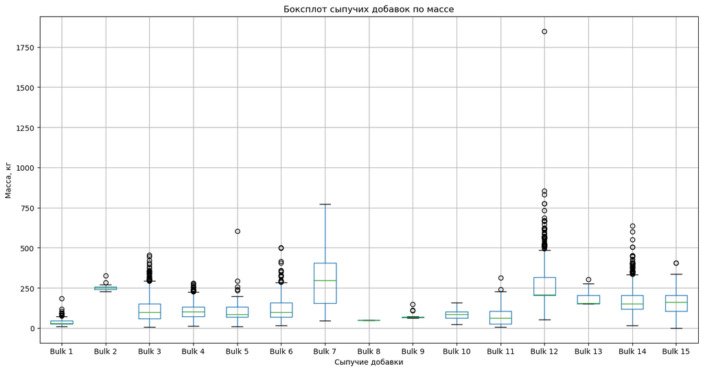

```python
p = data[1].drop(['key'], axis=1).columns.tolist()# Составим список объектов
box_plot=data[1].drop(['key'], axis=1).boxplot(column=p, grid= True, figsize=(16, 8));# Распределение значений
#сыпучих добавок
box_plot.set(xlabel='Сыпучие добавки',ylabel='Масса, кг', title='Боксплот сыпучих добавок по массе');
```

```python
data[1] = data[1].fillna(0).astype('uint16')# Заменяем пропуски 0 и изменяем тип данных object -> uint16
print(data[1].info())
data[1]
```

```
<class 'pandas.core.frame.DataFrame'>
Int64Index: 3129 entries, 0 to 3128
Data columns (total 16 columns):
 #   Column   Non-Null Count  Dtype
---  ------   --------------  -----
 0   key      3129 non-null   uint16
 1   Bulk 1   3129 non-null   uint16
 2   Bulk 2   3129 non-null   uint16
 3   Bulk 3   3129 non-null   uint16
 4   Bulk 4   3129 non-null   uint16
 5   Bulk 5   3129 non-null   uint16
 6   Bulk 6   3129 non-null   uint16
 7   Bulk 7   3129 non-null   uint16
 8   Bulk 8   3129 non-null   uint16
 9   Bulk 9   3129 non-null   uint16
 10  Bulk 10  3129 non-null   uint16
 11  Bulk 11  3129 non-null   uint16
 12  Bulk 12  3129 non-null   uint16
 13  Bulk 13  3129 non-null   uint16
 14  Bulk 14  3129 non-null   uint16
 15  Bulk 15  3129 non-null   uint16
dtypes: uint16(16)
memory usage: 122.2 KB
None
```

|  | key | Bulk 1 | Bulk 2 | Bulk 3 | Bulk 4 | Bulk 5 | Bulk 6 | Bulk 7 | Bulk 8 | Bulk 9 | Bulk 10 | Bulk 11 | Bulk 12 | Bulk 13 | Bulk 14 | Bulk 15 |
| --- | --- | --- | --- | --- | --- | --- | --- | --- | --- | --- | --- | --- | --- | --- | --- | --- |
| 0 | 1 | 0 | 0 | 0 | 43 | 0 | 0 | 0 | 0 | 0 | 0 | 0 | 206 | 0 | 150 | 154 |
| 1 | 2 | 0 | 0 | 0 | 73 | 0 | 0 | 0 | 0 | 0 | 0 | 0 | 206 | 0 | 149 | 154 |
| 2 | 3 | 0 | 0 | 0 | 34 | 0 | 0 | 0 | 0 | 0 | 0 | 0 | 205 | 0 | 152 | 153 |
| 3 | 4 | 0 | 0 | 0 | 81 | 0 | 0 | 0 | 0 | 0 | 0 | 0 | 207 | 0 | 153 | 154 |
| 4 | 5 | 0 | 0 | 0 | 78 | 0 | 0 | 0 | 0 | 0 | 0 | 0 | 203 | 0 | 151 | 152 |
| ... | ... | ... | ... | ... | ... | ... | ... | ... | ... | ... | ... | ... | ... | ... | ... | ... |
| 3124 | 3237 | 0 | 0 | 170 | 0 | 0 | 0 | 0 | 0 | 0 | 0 | 0 | 252 | 0 | 130 | 206 |
| 3125 | 3238 | 0 | 0 | 126 | 0 | 0 | 0 | 0 | 0 | 0 | 0 | 0 | 254 | 0 | 108 | 106 |
| 3126 | 3239 | 0 | 0 | 0 | 0 | 0 | 114 | 0 | 0 | 0 | 0 | 0 | 158 | 0 | 270 | 88 |
| 3127 | 3240 | 0 | 0 | 0 | 0 | 0 | 26 | 0 | 0 | 0 | 0 | 0 | 0 | 0 | 192 | 54 |
| 3128 | 3241 | 0 | 0 | 0 | 0 | 0 | 0 | 0 | 0 | 0 | 0 | 0 | 0 | 0 | 180 | 52 |

3129 rows × 16 columns

Вывод: Различное количество партий в группе `bulk` - 3129, а в arc - 3241. Необходимо для последующего анализа выбрать партии общие для всех групп.

#### `bulk _time` (data[2]) Сыпучие добавки. Время.

```python
print(name[2])
data[2]
```

```
bulk_time
```

|  | key | Bulk 1 | Bulk 2 | Bulk 3 | Bulk 4 | Bulk 5 | Bulk 6 | Bulk 7 | Bulk 8 | Bulk 9 | Bulk 10 | Bulk 11 | Bulk 12 | Bulk 13 | Bulk 14 | Bulk 15 |
| --- | --- | --- | --- | --- | --- | --- | --- | --- | --- | --- | --- | --- | --- | --- | --- | --- |
| 0 | 1 | NaN | NaN | NaN | 2019-05-03 11:28:48 | NaN | NaN | NaN | NaN | NaN | NaN | NaN | 2019-05-03 11:24:31 | NaN | 2019-05-03 11:14:50 | 2019-05-03 11:10:43 |
| 1 | 2 | NaN | NaN | NaN | 2019-05-03 11:36:50 | NaN | NaN | NaN | NaN | NaN | NaN | NaN | 2019-05-03 11:53:30 | NaN | 2019-05-03 11:48:37 | 2019-05-03 11:44:39 |
| 2 | 3 | NaN | NaN | NaN | 2019-05-03 12:32:39 | NaN | NaN | NaN | NaN | NaN | NaN | NaN | 2019-05-03 12:27:13 | NaN | 2019-05-03 12:21:01 | 2019-05-03 12:16:16 |
| 3 | 4 | NaN | NaN | NaN | 2019-05-03 12:43:22 | NaN | NaN | NaN | NaN | NaN | NaN | NaN | 2019-05-03 12:58:00 | NaN | 2019-05-03 12:51:11 | 2019-05-03 12:46:36 |
| 4 | 5 | NaN | NaN | NaN | 2019-05-03 13:30:47 | NaN | NaN | NaN | NaN | NaN | NaN | NaN | 2019-05-03 13:30:47 | NaN | 2019-05-03 13:34:12 | 2019-05-03 13:30:47 |
| ... | ... | ... | ... | ... | ... | ... | ... | ... | ... | ... | ... | ... | ... | ... | ... | ... |
| 3124 | 3237 | NaN | NaN | 2019-09-06 11:54:15 | NaN | NaN | NaN | NaN | NaN | NaN | NaN | NaN | 2019-09-06 11:49:45 | NaN | 2019-09-06 11:45:22 | 2019-09-06 11:40:06 |
| 3125 | 3238 | NaN | NaN | 2019-09-06 12:26:52 | NaN | NaN | NaN | NaN | NaN | NaN | NaN | NaN | 2019-09-06 12:18:35 | NaN | 2019-09-06 12:31:49 | 2019-09-06 12:26:52 |
| 3126 | 3239 | NaN | NaN | NaN | NaN | NaN | 2019-09-06 15:06:00 | NaN | NaN | NaN | NaN | NaN | 2019-09-06 15:01:44 | NaN | 2019-09-06 14:58:15 | 2019-09-06 14:48:06 |
| 3127 | 3240 | NaN | NaN | NaN | NaN | NaN | 2019-09-06 16:24:28 | NaN | NaN | NaN | NaN | NaN | NaN | NaN | 2019-09-06 16:07:29 | 2019-09-06 16:01:34 |
| 3128 | 3241 | NaN | NaN | NaN | NaN | NaN | NaN | NaN | NaN | NaN | NaN | NaN | NaN | NaN | 2019-09-06 17:26:33 | 2019-09-06 17:23:15 |

3129 rows × 16 columns

```python
dc_2 = data[2].columns.tolist()[1:]
data[2][dc_2] = data[2][dc_2].astype("datetime64[ns]")
data[2].info()
```

```
<class 'pandas.core.frame.DataFrame'>
Int64Index: 3129 entries, 0 to 3128
Data columns (total 16 columns):
 #   Column   Non-Null Count  Dtype
---  ------   --------------  -----
 0   key      3129 non-null   uint16
 1   Bulk 1   252 non-null    datetime64[ns]
 2   Bulk 2   22 non-null     datetime64[ns]
 3   Bulk 3   1298 non-null   datetime64[ns]
 4   Bulk 4   1014 non-null   datetime64[ns]
 5   Bulk 5   77 non-null     datetime64[ns]
 6   Bulk 6   576 non-null    datetime64[ns]
 7   Bulk 7   25 non-null     datetime64[ns]
 8   Bulk 8   1 non-null      datetime64[ns]
 9   Bulk 9   19 non-null     datetime64[ns]
 10  Bulk 10  176 non-null    datetime64[ns]
 11  Bulk 11  177 non-null    datetime64[ns]
 12  Bulk 12  2450 non-null   datetime64[ns]
 13  Bulk 13  18 non-null     datetime64[ns]
 14  Bulk 14  2806 non-null   datetime64[ns]
 15  Bulk 15  2248 non-null   datetime64[ns]
dtypes: datetime64[ns](15), uint16(1)
memory usage: 397.2 KB
```

Вывод: Совпадает количество партий в группе `bulk` и в `bulk_time`.

#### `gas` (data[3]) Газ. Объём

```python
print(name[3])
data[3]
```

```
gas
```

|  | key | Газ 1 |
| --- | --- | --- |
| 0 | 1 | 29.749986 |
| 1 | 2 | 12.555561 |
| 2 | 3 | 28.554793 |
| 3 | 4 | 18.841219 |
| 4 | 5 | 5.413692 |
| ... | ... | ... |
| 3234 | 3237 | 5.543905 |
| 3235 | 3238 | 6.745669 |
| 3236 | 3239 | 16.023518 |
| 3237 | 3240 | 11.863103 |
| 3238 | 3241 | 12.680959 |

3239 rows × 2 columns

[output not shown]

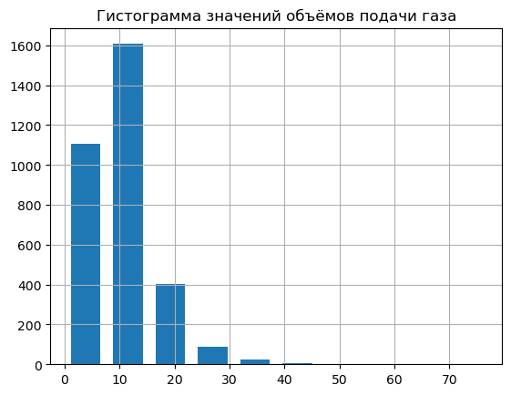

```python
data[3].drop(['key'], axis=1).hist(rwidth= .7)
plt.title('Гистограмма значений объёмов подачи газа');
data[3]['Газ 1'].describe()
```

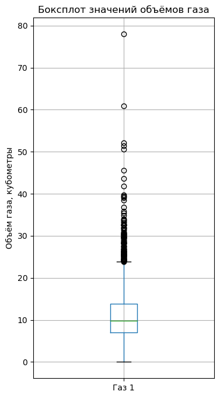

```python
p = data[3].drop(['key'], axis=1).columns.tolist()# Составим список объектов
box_plot=data[3].drop(['key'], axis=1).boxplot(column=p, grid= True, figsize=(4, 8));# Распределение значений газа
box_plot.set(xlabel='',ylabel='Объём газа, кубометры', title='Боксплот значений объёмов газа');
```

```python
data[3]['Газ 1'] = data[3]['Газ 1'].astype('uint8')# Изменяем тип данных int64 -> uint8
data[3].info()
```

```
<class 'pandas.core.frame.DataFrame'>
Int64Index: 3239 entries, 0 to 3238
Data columns (total 2 columns):
 #   Column  Non-Null Count  Dtype
---  ------  --------------  -----
 0   key     3239 non-null   uint16
 1   Газ 1   3239 non-null   uint8
dtypes: uint16(1), uint8(1)
memory usage: 34.8 KB
```

```python
# Проверим строки на уникальность партий. Группируем данные по 'key':
# count_key - количество строк одной партии
# gas_total - суммарное количество газа в партии
key_gas_groupby = data[3].groupby('key', as_index=False).agg(count_key = ('key', 'count'),
                  gas_total = ('Газ 1', 'sum'))
key_gas_groupby.sort_values(by='count_key', ascending=False)
k = key_gas_groupby.sort_values(by='count_key', ascending=False)
print(k.head(10))
```

```
       key  count_key  gas_total
0        1          1         29
2163  2166          1         24
2153  2156          1          8
2154  2157          1          7
2155  2158          1          8
2156  2159          1          6
2157  2160          1         17
2158  2161          1         11
2159  2162          1         17
2160  2163          1          6
```

Вывод:

-Каждая строка соответствует уникальной партии `key`, т.е. нет партии в которой бы мы имели два значения по газу;

-Пропущены две партии;

-Отсутствует хронология подачи газа.

#### `temp` (data[4]) Температура.

```python
print(name[4])
data[4]
```

```
temp
```

|  | key | Время замера | Температура |
| --- | --- | --- | --- |
| 0 | 1 | 2019-05-03 11:02:04 | 1571.0 |
| 1 | 1 | 2019-05-03 11:07:18 | 1604.0 |
| 2 | 1 | 2019-05-03 11:11:34 | 1618.0 |
| 3 | 1 | 2019-05-03 11:18:04 | 1601.0 |
| 4 | 1 | 2019-05-03 11:25:59 | 1606.0 |
| ... | ... | ... | ... |
| 18087 | 3241 | 2019-09-06 16:55:01 | NaN |
| 18088 | 3241 | 2019-09-06 17:06:38 | NaN |
| 18089 | 3241 | 2019-09-06 17:21:48 | NaN |
| 18090 | 3241 | 2019-09-06 17:24:44 | NaN |
| 18091 | 3241 | 2019-09-06 17:30:05 | NaN |

18092 rows × 3 columns

```python
data[4].info()
```

```
<class 'pandas.core.frame.DataFrame'>
Int64Index: 18092 entries, 0 to 18091
Data columns (total 3 columns):
 #   Column        Non-Null Count  Dtype
---  ------        --------------  -----
 0   key           18092 non-null  uint16
 1   Время замера  18092 non-null  object
 2   Температура   14665 non-null  float64
dtypes: float64(1), object(1), uint16(1)
memory usage: 459.4+ KB
```

```python
#Создадим копию data[4]
data_4 = data[4].copy()
```

```python
data[4] = data[4].dropna()# Удалим строки с пропусками
```

```python
data[4]['Время замера'] = data[4]['Время замера'].astype("datetime64[ns]")
data[4]['Температура'] = data[4]['Температура'].astype('uint16')# Изменяем тип данных int64 -> uint16
data[4].info()
```

```
<class 'pandas.core.frame.DataFrame'>
Int64Index: 14665 entries, 0 to 18086
Data columns (total 3 columns):
 #   Column        Non-Null Count  Dtype
---  ------        --------------  -----
 0   key           14665 non-null  uint16
 1   Время замера  14665 non-null  datetime64[ns]
 2   Температура   14665 non-null  uint16
dtypes: datetime64[ns](1), uint16(2)
memory usage: 286.4 KB
```

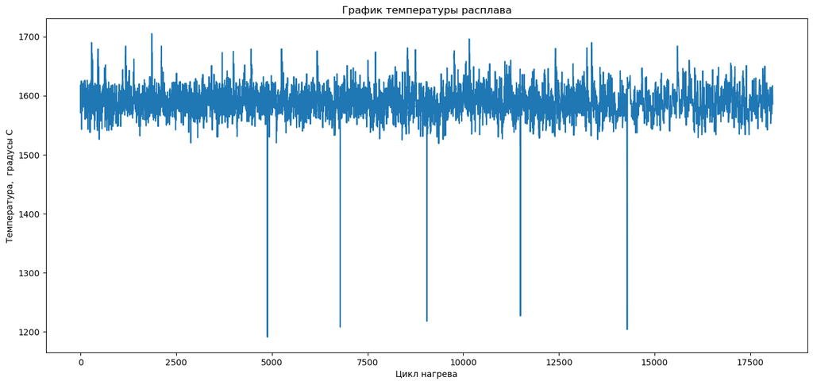

```python
plt.figure(figsize=(16, 24))
plt.subplot(311)
plt.xlabel("Цикл нагрева")
plt.ylabel('Температура,  градусы С')
data[4]['Температура'].plot(ax=plt.gca())
plt.title('График температуры расплава');
```

Вывод:

-Начиная со строки 13926 (партия 2500) в данных для всех партий присутствует только одна начальная температура. Следовательно данные партий с 2501 по 3241 не удастся использовать для прогнозирования;

-Количество замеров внутри партий различное;

-Существуют единичные просадки температуры ниже температуры плавления. Так например Партия: 867 Дата: 2019-06-06 08:03:39 Начальная температура: 1191.0. Энергии затрачено не более обычного (Партия: 867 Дата: 2019-06-06 08:03:49 Дата: 2019-06-06 08:06:04 Энергия: 183.891739), расход газа - так же средний (Партия: 867 Расход газа: 11.616807). Вероятно имеем дело с выбросами, нуждающимися в удалении.

#### `wire` (data[5]) Проволочные добавки. Масса.

```python
print(name[5])
data[5]
```

```
wire
```

|  | key | Wire 1 | Wire 2 | Wire 3 | Wire 4 | Wire 5 | Wire 6 | Wire 7 | Wire 8 | Wire 9 |
| --- | --- | --- | --- | --- | --- | --- | --- | --- | --- | --- |
| 0 | 1 | 60.059998 | NaN | NaN | NaN | NaN | NaN | NaN | NaN | NaN |
| 1 | 2 | 96.052315 | NaN | NaN | NaN | NaN | NaN | NaN | NaN | NaN |
| 2 | 3 | 91.160157 | NaN | NaN | NaN | NaN | NaN | NaN | NaN | NaN |
| 3 | 4 | 89.063515 | NaN | NaN | NaN | NaN | NaN | NaN | NaN | NaN |
| 4 | 5 | 89.238236 | 9.11456 | NaN | NaN | NaN | NaN | NaN | NaN | NaN |
| ... | ... | ... | ... | ... | ... | ... | ... | ... | ... | ... |
| 3076 | 3237 | 38.088959 | NaN | NaN | NaN | NaN | NaN | NaN | NaN | NaN |
| 3077 | 3238 | 56.128799 | NaN | NaN | NaN | NaN | NaN | NaN | NaN | NaN |
| 3078 | 3239 | 143.357761 | NaN | NaN | NaN | NaN | NaN | NaN | NaN | NaN |
| 3079 | 3240 | 34.070400 | NaN | NaN | NaN | NaN | NaN | NaN | NaN | NaN |
| 3080 | 3241 | 63.117595 | NaN | NaN | NaN | NaN | NaN | NaN | NaN | NaN |

3081 rows × 10 columns

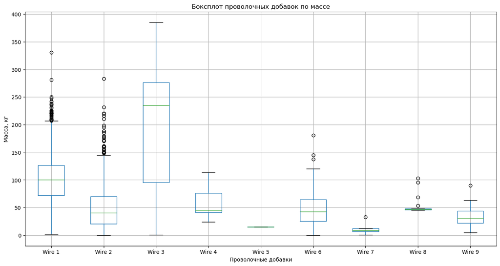

```python
p = data[5].drop(['key'], axis=1).columns.tolist()# Составим список объектов
box_plot=data[5].drop(['key'], axis=1).boxplot(column=p, grid= True, figsize=(16, 8));# Распределение значений
# сыпучих добавок
box_plot.set(xlabel='Проволочные добавки',ylabel='Масса, кг', title='Боксплот проволочных добавок по массе');
```

```python
data[5] = data[5].fillna(0).astype('uint16')# Заменяем пропуски 0 и изменяем тип данных int64 -> uint16
print(data[5].info())
data[5]
```

```
<class 'pandas.core.frame.DataFrame'>
Int64Index: 3081 entries, 0 to 3080
Data columns (total 10 columns):
 #   Column  Non-Null Count  Dtype
---  ------  --------------  -----
 0   key     3081 non-null   uint16
 1   Wire 1  3081 non-null   uint16
 2   Wire 2  3081 non-null   uint16
 3   Wire 3  3081 non-null   uint16
 4   Wire 4  3081 non-null   uint16
 5   Wire 5  3081 non-null   uint16
 6   Wire 6  3081 non-null   uint16
 7   Wire 7  3081 non-null   uint16
 8   Wire 8  3081 non-null   uint16
 9   Wire 9  3081 non-null   uint16
dtypes: uint16(10)
memory usage: 84.2 KB
None
```

|  | key | Wire 1 | Wire 2 | Wire 3 | Wire 4 | Wire 5 | Wire 6 | Wire 7 | Wire 8 | Wire 9 |
| --- | --- | --- | --- | --- | --- | --- | --- | --- | --- | --- |
| 0 | 1 | 60 | 0 | 0 | 0 | 0 | 0 | 0 | 0 | 0 |
| 1 | 2 | 96 | 0 | 0 | 0 | 0 | 0 | 0 | 0 | 0 |
| 2 | 3 | 91 | 0 | 0 | 0 | 0 | 0 | 0 | 0 | 0 |
| 3 | 4 | 89 | 0 | 0 | 0 | 0 | 0 | 0 | 0 | 0 |
| 4 | 5 | 89 | 9 | 0 | 0 | 0 | 0 | 0 | 0 | 0 |
| ... | ... | ... | ... | ... | ... | ... | ... | ... | ... | ... |
| 3076 | 3237 | 38 | 0 | 0 | 0 | 0 | 0 | 0 | 0 | 0 |
| 3077 | 3238 | 56 | 0 | 0 | 0 | 0 | 0 | 0 | 0 | 0 |
| 3078 | 3239 | 143 | 0 | 0 | 0 | 0 | 0 | 0 | 0 | 0 |
| 3079 | 3240 | 34 | 0 | 0 | 0 | 0 | 0 | 0 | 0 | 0 |
| 3080 | 3241 | 63 | 0 | 0 | 0 | 0 | 0 | 0 | 0 | 0 |

3081 rows × 10 columns

Вывод: Количество партий в группе `Wire` равно 3081.

#### `wire_time` (data[6]) Проволочные добавки. Время.

```python
print(name[6])
data[6]
```

```
wire_time
```

|  | key | Wire 1 | Wire 2 | Wire 3 | Wire 4 | Wire 5 | Wire 6 | Wire 7 | Wire 8 | Wire 9 |
| --- | --- | --- | --- | --- | --- | --- | --- | --- | --- | --- |
| 0 | 1 | 2019-05-03 11:06:19 | NaN | NaN | NaN | NaN | NaN | NaN | NaN | NaN |
| 1 | 2 | 2019-05-03 11:36:50 | NaN | NaN | NaN | NaN | NaN | NaN | NaN | NaN |
| 2 | 3 | 2019-05-03 12:11:46 | NaN | NaN | NaN | NaN | NaN | NaN | NaN | NaN |
| 3 | 4 | 2019-05-03 12:43:22 | NaN | NaN | NaN | NaN | NaN | NaN | NaN | NaN |
| 4 | 5 | 2019-05-03 13:20:44 | 2019-05-03 13:15:34 | NaN | NaN | NaN | NaN | NaN | NaN | NaN |
| ... | ... | ... | ... | ... | ... | ... | ... | ... | ... | ... |
| 3076 | 3237 | 2019-09-06 11:33:38 | NaN | NaN | NaN | NaN | NaN | NaN | NaN | NaN |
| 3077 | 3238 | 2019-09-06 12:18:35 | NaN | NaN | NaN | NaN | NaN | NaN | NaN | NaN |
| 3078 | 3239 | 2019-09-06 14:36:11 | NaN | NaN | NaN | NaN | NaN | NaN | NaN | NaN |
| 3079 | 3240 | 2019-09-06 15:33:55 | NaN | NaN | NaN | NaN | NaN | NaN | NaN | NaN |
| 3080 | 3241 | 2019-09-06 17:10:06 | NaN | NaN | NaN | NaN | NaN | NaN | NaN | NaN |

3081 rows × 10 columns

```python
dc_6 = data[6].columns.tolist()[1:]
data[6][dc_6] = data[6][dc_6].astype("datetime64[ns]")
data[6].info()
```

```
<class 'pandas.core.frame.DataFrame'>
Int64Index: 3081 entries, 0 to 3080
Data columns (total 10 columns):
 #   Column  Non-Null Count  Dtype
---  ------  --------------  -----
 0   key     3081 non-null   uint16
 1   Wire 1  3055 non-null   datetime64[ns]
 2   Wire 2  1079 non-null   datetime64[ns]
 3   Wire 3  63 non-null     datetime64[ns]
 4   Wire 4  14 non-null     datetime64[ns]
 5   Wire 5  1 non-null      datetime64[ns]
 6   Wire 6  73 non-null     datetime64[ns]
 7   Wire 7  11 non-null     datetime64[ns]
 8   Wire 8  19 non-null     datetime64[ns]
 9   Wire 9  29 non-null     datetime64[ns]
dtypes: datetime64[ns](9), uint16(1)
memory usage: 246.7 KB
```

Вывод: Совпадает количество партий в группе `Wire` и в группе `Wire_time`.

### Вывод по исследовательскому анализу данных

**('arc', 'bulk', 'bulk_time', 'gas', 'temp', 'wire', 'wire_time')**

- Дубликатов нет

**`arc`**

- Количество циклов нагрева в партиях разное.
- Единственное значение реактивной энергии меньше 0 - выброс.
- Необходимо уточнить допущенное предположение, что данные содержат значения средней за цикл, а не мгновенной мощности.

**`bulk`**

- Различное количество партий в группе `bulk` - 3129, а в `arc` - 3241. Необходимо для последующего анализа выбрать партии общие для всех групп.

**`bulk_time`**

- Совпадает количество партий в группе `bulk` и в `bulk_time`.

**`gas`**

- Каждая строка соответствует уникальной партии ('key'), т.е. нет партии в которой бы мы имели два значения по газу;
- Пропущены две партии при подачи газа;
- Отсутствует хронология подачи газа. Газ может подаваться непрерывно, может синхронно с лигирующими добавками, а может для снижения температуры. Для понимания процесса можно задать уточняющий вопрос о характере подачи газа на данном производстве.

**`temp`**

- Начиная со строки 13926 (партия 2500) в данных для всех партий присутствует только одна начальная температура (перстал работать прибор или научились прогнозировать температуру по начальной?). Следовательно данные партий с 2501 по 3241 не удастся использовать для прогнозирования;
- Количество замеров внутри партий различное;
- Существуют единичные просадки температуры ниже температуры плавления. Так например Партия: 867 Дата: 2019-06-06 08:03:39 Начальная температура: 1191.0. Энергии затрачено не более обычного (Партия: 867 Дата: 2019-06-06 08:03:49 Дата: 2019-06-06 08:06:04 Энергия: 183.891739), расход газа - так же средний (Партия: 867 Расход газа: 11.616807). Вероятно имеем дело с выбрасами, нуждающимися в удалении;

**`wire`**

- Количество партий в группе Wire равно 3081.

**`wire_time`**

- Совпадает количество партий в группе `Wire` и в группе `Wire_time`.

### Примерный план решения задачи

1. Получить ответы на уточняющие вопросы.
2. Составить список параметров необходимых для обучения модели.
3. Определиться, что будем считать выбросами. Удалить выбросы.
4. Агрегировать имеющиеся данные по партиям, рассчитать новые параметры. (В таблице `arc`, создать три новых параметра `Е_а`, `Е_р` и `dt` , соответствующих Активной и Реактивной энергии и длительности партии. В таблице `temp` создать два новых параметра `t_1` и `t_2`, соответствующие начальной и конечной температуре партии. Удалить неинформативные партии у которых отсутствует начальная или конечная температура.)
5. Объединить данные по методу INNER, оставив только те партии `key` которые присутствуют во всех объединяемых датасетах.
6. Вывести графики распределения всех признаков объединённого датасета.
7. Построить матрицу корреляций всех признаков в виде тепловой карты heatmap. При использовании линейной регрессии, удалить любой из признаков в каждой паре высококоррелирующих признаков (напр. >0.9).
8. Выполнить кросс-валидацию для 75% данных, на тестирование оставляем 25 % данных, выводим размеры полученных выборок.
9. Обучить не менее 2-х моделей с кросс-валидацией, подбор не менее 2-х наборов гиперпараметров с `GridSearchCV` или `RandomizedSearchCV` хотя бы у одной модели (к примеру, перебирать как `max_depth`, так и `min_samples_leaf`).
10. Выбрать лучшую модель по `.best_score_`. Для лучшей модели рассчитаем метрику `r2` на тестовой выборке и интерпретируем её.
11. Тестировать лучшую модель, провести её сравнение с константной моделью `DummyRegressor` (обучение на трейне, предсказание на тестовой выборке).
12. Исследование важности признаков у лучшей модели. Сделать вывод по важности признаков.

### Список уточняющих вопросов и полученные ответы

1. Какие единицы измерений у всех параметров кроме времени?
2. Данные первого датасета содержат значения средней за цикл нагрева или мгновенной мощности?
3. Газ может подаваться непрерывно, может синхронно с лигирующими добавками, а может для снижения температуры. Какой характер подачи газа на данном производстве?
4. Начиная со строки 13926 (партия 2500) в данных для всех партий присутствует только одна начальная температура. Перстал работать прибор?
5. Существуют единичные просадки температуры ниже температуры плавления. Так например Партия: 867 Дата: 2019-06-06 08:03:39 Начальная температура: 1191.0. Как объясняется данное понижение температуры?
6. Есть ли на данном производстве уставки ограничивающие мощность и/или энергию передаваемую на электроды? Каковы их значения?
1. Температура - градусы цельсия, мощность - мВт, материалы - кг, газ - м3
2. среднее за цикл нагрева
3. Газ подается после добавления материалов, с целью их перемешивания
4. Это сбои в измерительном оборудовании, такие партии нужно удалить
5. сбои в измерительном оборудовании, такие партии нужно удалить
6. такие установки возможно есть, но их значения неизвестны

## Основная часть

### Предобработка данных

Составим список параметров необходимых для обучения модели:

- `e_а` - суммарная за партию Активная энергия из `arc`;
- `e_р` - суммарная за партию Реактивная энергия из `arc`;
- `dt` - длительности партии из `temp`;
- `t_1` - начальная температура партии из `temp`;
- `t_2` - конечная температура партии из `temp`;
- `g` - значения параметра `Газ 1` из `gas`;
- `b` - суммарное значение за партию всех 15 параметров `Bulk`;
- `w` - суммарное значение за партию всех 9 параметров `Wire`.

Определимся, что будем считать выбросами:

- Реактивную мощность меньше 0 из `arc` - удалим данную партию;
- Данные с нарушением хронологии - удалим такие партии;
- Температуру `T_1` и `T_2` меньшую 1500 из `temp` - удалим такие партии.

### Удаление партии в которой была отрицательная мощность

```python
# Получаем значение партии в которой была отрицательная мощность
k = data[0].loc[data[0]['Реактивная мощность']<0, 'key']. values [0]
data[0] = data[0][data[0]['key'] != k]# Удаляем эту партию из датасета
data[0]['Реактивная мощность'].min()# Проверяем, что удаление выполнилии
```

```
0.15377700328826904
```

### Агрегируем имеющиеся данные по партиям и рассчитаем новые параметры.

#### `temp` (data[4]) Температура.

В данном случае работать будем с исходным датасетом сохранённым до удаления пропусков.

```python
t = data_4
data_4.info()
display(data_4)
pd.DataFrame(round(data_4.isna().mean()*100,)).style.background_gradient('coolwarm')
```

```
<class 'pandas.core.frame.DataFrame'>
Int64Index: 18092 entries, 0 to 18091
Data columns (total 3 columns):
 #   Column        Non-Null Count  Dtype
---  ------        --------------  -----
 0   key           18092 non-null  uint16
 1   Время замера  18092 non-null  object
 2   Температура   14665 non-null  float64
dtypes: float64(1), object(1), uint16(1)
memory usage: 459.4+ KB
```

|  | key | Время замера | Температура |
| --- | --- | --- | --- |
| 0 | 1 | 2019-05-03 11:02:04 | 1571.0 |
| 1 | 1 | 2019-05-03 11:07:18 | 1604.0 |
| 2 | 1 | 2019-05-03 11:11:34 | 1618.0 |
| 3 | 1 | 2019-05-03 11:18:04 | 1601.0 |
| 4 | 1 | 2019-05-03 11:25:59 | 1606.0 |
| ... | ... | ... | ... |
| 18087 | 3241 | 2019-09-06 16:55:01 | NaN |
| 18088 | 3241 | 2019-09-06 17:06:38 | NaN |
| 18089 | 3241 | 2019-09-06 17:21:48 | NaN |
| 18090 | 3241 | 2019-09-06 17:24:44 | NaN |
| 18091 | 3241 | 2019-09-06 17:30:05 | NaN |

18092 rows × 3 columns

|  | 0 |
| --- | --- |
| key | 0.000000 |
| Время замера | 0.000000 |
| Температура | 19.000000 |

```python
n = 0
t['t1'] = '2000-01-01 00:00:00' # Время первого замера в партии
t['t2'] = '2000-01-01 00:00:00' # Время последнего замера в партии
t['T_1'] = 0 # Начальная температура в партии
t['T_2'] = 0 # Конечная температура в партии
for j in t.index.tolist():
    if t['key'][j] > n:# Если номер партии увеличился
        n = t['key'][j]# Скорректируем номер текущей партии
        t['T_1'][j] = t['Температура'][j]# Фиксируем начальную температуру текущей партии
        t['t1'][j] = t['Время замера'][j]# Время первого замера
        if j > 0:# Если это не первая строка
            t['T_2'][j-1] = t['Температура'][j-1]# Предыдущая строка содержит конечную температуру
            # предыдущей партии
            t['t2'][j-1] = t['Время замера'][j-1]# Предыдущая строка содержит время последнего
            # замера предыдущей партии
t
```

|  | key | Время замера | Температура | t1 | t2 | T_1 | T_2 |
| --- | --- | --- | --- | --- | --- | --- | --- |
| 0 | 1 | 2019-05-03 11:02:04 | 1571.0 | 2019-05-03 11:02:04 | 2000-01-01 00:00:00 | 1571 | 0.0 |
| 1 | 1 | 2019-05-03 11:07:18 | 1604.0 | 2000-01-01 00:00:00 | 2000-01-01 00:00:00 | 0 | 0.0 |
| 2 | 1 | 2019-05-03 11:11:34 | 1618.0 | 2000-01-01 00:00:00 | 2000-01-01 00:00:00 | 0 | 0.0 |
| 3 | 1 | 2019-05-03 11:18:04 | 1601.0 | 2000-01-01 00:00:00 | 2000-01-01 00:00:00 | 0 | 0.0 |
| 4 | 1 | 2019-05-03 11:25:59 | 1606.0 | 2000-01-01 00:00:00 | 2000-01-01 00:00:00 | 0 | 0.0 |
| ... | ... | ... | ... | ... | ... | ... | ... |
| 18087 | 3241 | 2019-09-06 16:55:01 | NaN | 2000-01-01 00:00:00 | 2000-01-01 00:00:00 | 0 | 0.0 |
| 18088 | 3241 | 2019-09-06 17:06:38 | NaN | 2000-01-01 00:00:00 | 2000-01-01 00:00:00 | 0 | 0.0 |
| 18089 | 3241 | 2019-09-06 17:21:48 | NaN | 2000-01-01 00:00:00 | 2000-01-01 00:00:00 | 0 | 0.0 |
| 18090 | 3241 | 2019-09-06 17:24:44 | NaN | 2000-01-01 00:00:00 | 2000-01-01 00:00:00 | 0 | 0.0 |
| 18091 | 3241 | 2019-09-06 17:30:05 | NaN | 2000-01-01 00:00:00 | 2000-01-01 00:00:00 | 0 | 0.0 |

18092 rows × 7 columns

```python
t = t.drop(['Время замера', 'Температура'], axis=1)
t['t1'] = t['t1'].astype("datetime64[ns]") # Изменяем тип данных object -> datetime64
t['t2'] = t['t2'].astype("datetime64[ns]")
t.info()
```

```
<class 'pandas.core.frame.DataFrame'>
Int64Index: 18092 entries, 0 to 18091
Data columns (total 5 columns):
 #   Column  Non-Null Count  Dtype
---  ------  --------------  -----
 0   key     18092 non-null  uint16
 1   t1      18092 non-null  datetime64[ns]
 2   t2      18092 non-null  datetime64[ns]
 3   T_1     18092 non-null  int64
 4   T_2     17354 non-null  float64
dtypes: datetime64[ns](2), float64(1), int64(1), uint16(1)
memory usage: 1.2 MB
```

```python
# Группируем данные по партям и создаём столбцы:
# t1 Время первого замера в партии
# t2 Время последнего замера в партии
# T_1 Начальная температура в партии
# T_2 Конечная температура в партии
temp = t.groupby('key').agg(t1 = ('t1', 'max'),t2 = ('t2', 'max'),T_1 = ('T_1', 'max'),T_2 = ('T_2', 'max'))
temp = temp.loc[temp['T_2'] > 0]# Оставляем данные где есть T_2
temp['dt'] = (temp['t2'] - temp['t1']).dt.total_seconds().astype('uint16')# Время партии в секундах
#temp = temp.drop(['t1', 't2'], axis=1)# Удаляем столбцы 't1', 't2'
temp = temp.loc[temp['T_1'] > 1500]
temp['T_1'] = temp['T_1'].astype('uint16')# Изменяем тип данных object -> uint16
temp['T_2'] = temp['T_2'].astype('uint16')
temp.info()
```

```
<class 'pandas.core.frame.DataFrame'>
UInt64Index: 2473 entries, 1 to 2499
Data columns (total 5 columns):
 #   Column  Non-Null Count  Dtype
---  ------  --------------  -----
 0   t1      2473 non-null   datetime64[ns]
 1   t2      2473 non-null   datetime64[ns]
 2   T_1     2473 non-null   uint16
 3   T_2     2473 non-null   uint16
 4   dt      2473 non-null   uint16
dtypes: datetime64[ns](2), uint16(3)
memory usage: 72.5 KB
```

```python
temp
```

| key | t1 | t2 | T_1 | T_2 | dt |
| --- | --- | --- | --- | --- | --- |
| 1 | 2019-05-03 11:02:04 | 2019-05-03 11:30:38 | 1571 | 1613 | 1714 |
| 2 | 2019-05-03 11:34:04 | 2019-05-03 11:55:09 | 1581 | 1602 | 1265 |
| 3 | 2019-05-03 12:06:44 | 2019-05-03 12:35:57 | 1596 | 1599 | 1753 |
| 4 | 2019-05-03 12:39:27 | 2019-05-03 12:59:47 | 1601 | 1625 | 1220 |
| 5 | 2019-05-03 13:11:03 | 2019-05-03 13:36:39 | 1576 | 1602 | 1536 |
| ... | ... | ... | ... | ... | ... |
| 2495 | 2019-08-10 11:27:47 | 2019-08-10 11:50:47 | 1570 | 1591 | 1380 |
| 2496 | 2019-08-10 11:56:48 | 2019-08-10 12:25:13 | 1554 | 1591 | 1705 |
| 2497 | 2019-08-10 12:37:26 | 2019-08-10 12:53:28 | 1571 | 1589 | 962 |
| 2498 | 2019-08-10 12:58:11 | 2019-08-10 13:23:31 | 1591 | 1594 | 1520 |
| 2499 | 2019-08-10 13:33:21 | 2019-08-10 13:58:58 | 1569 | 1603 | 1537 |

2473 rows × 5 columns

```python
temp['t1'].is_monotonic # Проверяем данные на монотонность
```

```
True
```

```python
temp['dt'].describe()# Проверяем, что нет подозрительных значений
```

```
count     2473.000000
mean      2279.472705
std       1375.318051
min          0.000000
25%       1541.000000
50%       2007.000000
75%       2739.000000
max      23674.000000
Name: dt, dtype: float64
```

```python
data[0]['Начало нагрева дугой'].is_monotonic # Проверяем данные на монотонность
```

```
True
```

#### `arc` (data[0]) Циклы нагрева. Мощность.

```python
 #'arc'
# Группируем данные по партям и создаём столбцы:
# e_а - суммарная за партию Активная энергия
# e_р - суммарная за партию Реактивная энергия
# t1_ - Время начала первого нагрева дугой в партии
# t2_ - Время начала последнего нагрева дугой в партии
arc = data[0].groupby('key').agg(e_а = ('E_a', 'sum'), e_p = ('E_p', 'sum'),
             t1_ = ('Начало нагрева дугой', 'min'), t2_ = ('Конец нагрева дугой', 'max'))
#arc['e_а'] = arc['e_а'].astype('float16')# Изменяем тип данных float32 -> float16
#arc['e_p'] = arc['e_p'].astype('float16')
display(arc)
arc.info()
```

| key | e_а | e_p | t1_ | t2_ |
| --- | --- | --- | --- | --- |
| 1 | 628.616943 | 444.489441 | 2019-05-03 11:02:14 | 2019-05-03 11:28:37 |
| 2 | 395.281799 | 274.690002 | 2019-05-03 11:34:14 | 2019-05-03 11:53:18 |
| 3 | 581.774658 | 428.038910 | 2019-05-03 12:06:54 | 2019-05-03 12:32:19 |
| 4 | 543.710266 | 413.941956 | 2019-05-03 12:39:37 | 2019-05-03 12:57:50 |
| 5 | 412.180450 | 303.070923 | 2019-05-03 13:11:13 | 2019-05-03 13:33:55 |
| ... | ... | ... | ... | ... |
| 3237 | 493.152191 | 392.740692 | 2019-09-06 11:31:25 | 2019-09-06 11:53:55 |
| 3238 | 229.390854 | 170.632904 | 2019-09-06 12:16:25 | 2019-09-06 12:31:35 |
| 3239 | 751.674866 | 563.798096 | 2019-09-06 14:17:00 | 2019-09-06 15:05:50 |
| 3240 | 530.736206 | 386.736145 | 2019-09-06 15:25:31 | 2019-09-06 16:24:15 |
| 3241 | 438.456451 | 312.035736 | 2019-09-06 16:49:05 | 2019-09-06 17:26:15 |

3213 rows × 4 columns

```
<class 'pandas.core.frame.DataFrame'>
UInt64Index: 3213 entries, 1 to 3241
Data columns (total 4 columns):
 #   Column  Non-Null Count  Dtype
---  ------  --------------  -----
 0   e_а     3213 non-null   float32
 1   e_p     3213 non-null   float32
 2   t1_     3213 non-null   datetime64[ns]
 3   t2_     3213 non-null   datetime64[ns]
dtypes: datetime64[ns](2), float32(2)
memory usage: 100.4 KB
```

```python
df = temp.merge(arc, on='key') # Объединим датасеты 'arc' и 'temp' в основной датасет 'df'.
display(df)
df.info()
```

| key | t1 | t2 | T_1 | T_2 | dt | e_а | e_p | t1_ | t2_ |
| --- | --- | --- | --- | --- | --- | --- | --- | --- | --- |
| 1 | 2019-05-03 11:02:04 | 2019-05-03 11:30:38 | 1571 | 1613 | 1714 | 628.616943 | 444.489441 | 2019-05-03 11:02:14 | 2019-05-03 11:28:37 |
| 2 | 2019-05-03 11:34:04 | 2019-05-03 11:55:09 | 1581 | 1602 | 1265 | 395.281799 | 274.690002 | 2019-05-03 11:34:14 | 2019-05-03 11:53:18 |
| 3 | 2019-05-03 12:06:44 | 2019-05-03 12:35:57 | 1596 | 1599 | 1753 | 581.774658 | 428.038910 | 2019-05-03 12:06:54 | 2019-05-03 12:32:19 |
| 4 | 2019-05-03 12:39:27 | 2019-05-03 12:59:47 | 1601 | 1625 | 1220 | 543.710266 | 413.941956 | 2019-05-03 12:39:37 | 2019-05-03 12:57:50 |
| 5 | 2019-05-03 13:11:03 | 2019-05-03 13:36:39 | 1576 | 1602 | 1536 | 412.180450 | 303.070923 | 2019-05-03 13:11:13 | 2019-05-03 13:33:55 |
| ... | ... | ... | ... | ... | ... | ... | ... | ... | ... |
| 2495 | 2019-08-10 11:27:47 | 2019-08-10 11:50:47 | 1570 | 1591 | 1380 | 571.539307 | 392.280701 | 2019-08-10 11:27:57 | 2019-08-10 11:48:05 |
| 2496 | 2019-08-10 11:56:48 | 2019-08-10 12:25:13 | 1554 | 1591 | 1705 | 675.222473 | 456.987244 | 2019-08-10 11:56:58 | 2019-08-10 12:23:07 |
| 2497 | 2019-08-10 12:37:26 | 2019-08-10 12:53:28 | 1571 | 1589 | 962 | 680.326660 | 462.862793 | 2019-08-10 12:37:36 | 2019-08-10 12:51:20 |
| 2498 | 2019-08-10 12:58:11 | 2019-08-10 13:23:31 | 1591 | 1594 | 1520 | 474.918793 | 335.536224 | 2019-08-10 12:58:21 | 2019-08-10 13:20:59 |
| 2499 | 2019-08-10 13:33:21 | 2019-08-10 13:58:58 | 1569 | 1603 | 1537 | 427.922546 | 316.073212 | 2019-08-10 13:33:31 | 2019-08-10 13:56:17 |

2470 rows × 9 columns

```
<class 'pandas.core.frame.DataFrame'>
UInt64Index: 2470 entries, 1 to 2499
Data columns (total 9 columns):
 #   Column  Non-Null Count  Dtype
---  ------  --------------  -----
 0   t1      2470 non-null   datetime64[ns]
 1   t2      2470 non-null   datetime64[ns]
 2   T_1     2470 non-null   uint16
 3   T_2     2470 non-null   uint16
 4   dt      2470 non-null   uint16
 5   e_а     2470 non-null   float32
 6   e_p     2470 non-null   float32
 7   t1_     2470 non-null   datetime64[ns]
 8   t2_     2470 non-null   datetime64[ns]
dtypes: datetime64[ns](4), float32(2), uint16(3)
memory usage: 130.3 KB
```

```python
df = df.loc[(df['t1_'] > df['t1']) & (df['t2_'] < df['t2'])] # Удалим из основного датасета данные с
# нарушением хронологии
df = df.drop(['t1_', 't2_'], axis=1) # Удалим из финальной таблицы 't1_', 't2_'
df.info()
```

```
<class 'pandas.core.frame.DataFrame'>
UInt64Index: 2470 entries, 1 to 2499
Data columns (total 7 columns):
 #   Column  Non-Null Count  Dtype
---  ------  --------------  -----
 0   t1      2470 non-null   datetime64[ns]
 1   t2      2470 non-null   datetime64[ns]
 2   T_1     2470 non-null   uint16
 3   T_2     2470 non-null   uint16
 4   dt      2470 non-null   uint16
 5   e_а     2470 non-null   float32
 6   e_p     2470 non-null   float32
dtypes: datetime64[ns](2), float32(2), uint16(3)
memory usage: 91.7 KB
```

Данных с нарушением хронологии не было

#### `bulk` (data[1]) Сыпучие добавки. Масса.

```python
 #'bulk'
p = data[1].drop(['key'], axis=1).columns.tolist()# Составим список из всех объектов кроме партии
data[1]['b_sum'] = 0 # b_sum - суммарное значение параметров в строке
for _ in p:
    data[1]['b_sum'] += data[1][_]
# Группируем данные по партям и создаём дополнительный столбец:
# b - суммарное значение за партию всех 15 параметров Bulk
bulk = data[1].groupby('key').agg(b = ('b_sum', 'sum'),
        b1 = ('Bulk 1', 'sum'), b2 = ('Bulk 2', 'sum'), b3 = ('Bulk 3', 'sum'), b4 = ('Bulk 4', 'sum'),
        b5 = ('Bulk 5', 'sum'),b6 = ('Bulk 6', 'sum'), b7 = ('Bulk 7', 'sum'), b8 = ('Bulk 8', 'sum'),
        b9 = ('Bulk 9', 'sum'), b10 = ('Bulk 10', 'sum'),b11 = ('Bulk 11', 'sum'), b12 = ('Bulk 12', 'sum'),
        b13 = ('Bulk 13', 'sum'), b14 = ('Bulk 14', 'sum'), b15 = ('Bulk 15', 'sum'))
bulk['b'] = bulk['b'].astype('uint16')# Изменяем тип данных object -> uint16
data[1] = data[1].drop(['b_sum'], axis=1)
# Объединим датасеты 'df' и 'bulk' в основной датасет 'df'.
df = df.merge(bulk, on='key')
display(df)
df.info()
```

| key | t1 | t2 | T_1 | T_2 | dt | e_а | e_p | b | b1 | b2 | ... | b6 | b7 | b8 | b9 | b10 | b11 | b12 | b13 | b14 | b15 |
| --- | --- | --- | --- | --- | --- | --- | --- | --- | --- | --- | --- | --- | --- | --- | --- | --- | --- | --- | --- | --- | --- |
| 1 | 2019-05-03 11:02:04 | 2019-05-03 11:30:38 | 1571 | 1613 | 1714 | 628.616943 | 444.489441 | 553 | 0 | 0 | ... | 0 | 0 | 0 | 0 | 0 | 0 | 206 | 0 | 150 | 154 |
| 2 | 2019-05-03 11:34:04 | 2019-05-03 11:55:09 | 1581 | 1602 | 1265 | 395.281799 | 274.690002 | 582 | 0 | 0 | ... | 0 | 0 | 0 | 0 | 0 | 0 | 206 | 0 | 149 | 154 |
| 3 | 2019-05-03 12:06:44 | 2019-05-03 12:35:57 | 1596 | 1599 | 1753 | 581.774658 | 428.038910 | 544 | 0 | 0 | ... | 0 | 0 | 0 | 0 | 0 | 0 | 205 | 0 | 152 | 153 |
| 4 | 2019-05-03 12:39:27 | 2019-05-03 12:59:47 | 1601 | 1625 | 1220 | 543.710266 | 413.941956 | 595 | 0 | 0 | ... | 0 | 0 | 0 | 0 | 0 | 0 | 207 | 0 | 153 | 154 |
| 5 | 2019-05-03 13:11:03 | 2019-05-03 13:36:39 | 1576 | 1602 | 1536 | 412.180450 | 303.070923 | 584 | 0 | 0 | ... | 0 | 0 | 0 | 0 | 0 | 0 | 203 | 0 | 151 | 152 |
| ... | ... | ... | ... | ... | ... | ... | ... | ... | ... | ... | ... | ... | ... | ... | ... | ... | ... | ... | ... | ... | ... |
| 2495 | 2019-08-10 11:27:47 | 2019-08-10 11:50:47 | 1570 | 1591 | 1380 | 571.539307 | 392.280701 | 719 | 0 | 0 | ... | 0 | 0 | 0 | 0 | 90 | 0 | 256 | 0 | 129 | 223 |
| 2496 | 2019-08-10 11:56:48 | 2019-08-10 12:25:13 | 1554 | 1591 | 1705 | 675.222473 | 456.987244 | 796 | 0 | 0 | ... | 0 | 0 | 0 | 0 | 122 | 0 | 256 | 0 | 129 | 226 |
| 2497 | 2019-08-10 12:37:26 | 2019-08-10 12:53:28 | 1571 | 1589 | 962 | 680.326660 | 462.862793 | 665 | 0 | 0 | ... | 0 | 0 | 0 | 0 | 0 | 0 | 230 | 0 | 124 | 226 |
| 2498 | 2019-08-10 12:58:11 | 2019-08-10 13:23:31 | 1591 | 1594 | 1520 | 474.918793 | 335.536224 | 733 | 0 | 0 | ... | 0 | 0 | 0 | 0 | 101 | 0 | 206 | 0 | 129 | 207 |
| 2499 | 2019-08-10 13:33:21 | 2019-08-10 13:58:58 | 1569 | 1603 | 1537 | 427.922546 | 316.073212 | 633 | 0 | 0 | ... | 0 | 0 | 0 | 0 | 0 | 0 | 233 | 0 | 126 | 227 |

2402 rows × 23 columns

```
<class 'pandas.core.frame.DataFrame'>
UInt64Index: 2402 entries, 1 to 2499
Data columns (total 23 columns):
 #   Column  Non-Null Count  Dtype
---  ------  --------------  -----
 0   t1      2402 non-null   datetime64[ns]
 1   t2      2402 non-null   datetime64[ns]
 2   T_1     2402 non-null   uint16
 3   T_2     2402 non-null   uint16
 4   dt      2402 non-null   uint16
 5   e_а     2402 non-null   float32
 6   e_p     2402 non-null   float32
 7   b       2402 non-null   uint16
 8   b1      2402 non-null   uint16
 9   b2      2402 non-null   uint16
 10  b3      2402 non-null   uint16
 11  b4      2402 non-null   uint16
 12  b5      2402 non-null   uint16
 13  b6      2402 non-null   uint16
 14  b7      2402 non-null   uint16
 15  b8      2402 non-null   uint16
 16  b9      2402 non-null   uint16
 17  b10     2402 non-null   uint16
 18  b11     2402 non-null   uint16
 19  b12     2402 non-null   uint16
 20  b13     2402 non-null   uint16
 21  b14     2402 non-null   uint16
 22  b15     2402 non-null   uint16
dtypes: datetime64[ns](2), float32(2), uint16(19)
memory usage: 164.2 KB
```

#### `bulk _time` (data[2]) Сыпучие добавки. Время.

```python
 #'bulk_time'
# Проверим что дата/время каждого процесса засыпки надятся внутри временного диапазона данной партии
q = data[2].copy() # Упростим название и сохраним исходные данные
p = data[2].drop(['key'], axis=1).columns.tolist()# Составим список из всех объектов кроме партии
q['t1_'] = '2100-01-01 00:00:00' # Время первого процесса в партии
q['t2_'] = '2000-01-01 00:00:00' # Время последнего процесса в партии
q['t1_'] = q['t1_'].astype("datetime64[ns]") # Время первого процесса в партии
q['t2_'] = q['t2_'].astype("datetime64[ns]") # Время последнего процесса в партии
for j in q['t1_'].index.tolist():
    for i in p:
        if q[i][j] < q['t1_'][j]:
            q['t1_'][j] = q[i][j]
        if q[i][j] > q['t2_'][j]:
            q['t2_'][j] = q[i][j]

q = q[['key', 't1_', 't2_']]
bulk_time = q.groupby('key').agg(t1_ = ('t1_', 'min'), t2_ = ('t2_', 'max'))

bulk_time
```

| key | t1_ | t2_ |
| --- | --- | --- |
| 1 | 2019-05-03 11:10:43 | 2019-05-03 11:28:48 |
| 2 | 2019-05-03 11:36:50 | 2019-05-03 11:53:30 |
| 3 | 2019-05-03 12:16:16 | 2019-05-03 12:32:39 |
| 4 | 2019-05-03 12:43:22 | 2019-05-03 12:58:00 |
| 5 | 2019-05-03 13:30:47 | 2019-05-03 13:34:12 |
| ... | ... | ... |
| 3237 | 2019-09-06 11:40:06 | 2019-09-06 11:54:15 |
| 3238 | 2019-09-06 12:18:35 | 2019-09-06 12:31:49 |
| 3239 | 2019-09-06 14:48:06 | 2019-09-06 15:06:00 |
| 3240 | 2019-09-06 16:01:34 | 2019-09-06 16:24:28 |
| 3241 | 2019-09-06 17:23:15 | 2019-09-06 17:26:33 |

3129 rows × 2 columns

```python
# Объединим датасеты 'df' и 'bulk_time' в основной датасет 'df'.
df = df.merge(bulk_time, on='key')
display(df)
df.info()
```

| key | t1 | t2 | T_1 | T_2 | dt | e_а | e_p | b | b1 | b2 | ... | b8 | b9 | b10 | b11 | b12 | b13 | b14 | b15 | t1_ | t2_ |
| --- | --- | --- | --- | --- | --- | --- | --- | --- | --- | --- | --- | --- | --- | --- | --- | --- | --- | --- | --- | --- | --- |
| 1 | 2019-05-03 11:02:04 | 2019-05-03 11:30:38 | 1571 | 1613 | 1714 | 628.616943 | 444.489441 | 553 | 0 | 0 | ... | 0 | 0 | 0 | 0 | 206 | 0 | 150 | 154 | 2019-05-03 11:10:43 | 2019-05-03 11:28:48 |
| 2 | 2019-05-03 11:34:04 | 2019-05-03 11:55:09 | 1581 | 1602 | 1265 | 395.281799 | 274.690002 | 582 | 0 | 0 | ... | 0 | 0 | 0 | 0 | 206 | 0 | 149 | 154 | 2019-05-03 11:36:50 | 2019-05-03 11:53:30 |
| 3 | 2019-05-03 12:06:44 | 2019-05-03 12:35:57 | 1596 | 1599 | 1753 | 581.774658 | 428.038910 | 544 | 0 | 0 | ... | 0 | 0 | 0 | 0 | 205 | 0 | 152 | 153 | 2019-05-03 12:16:16 | 2019-05-03 12:32:39 |
| 4 | 2019-05-03 12:39:27 | 2019-05-03 12:59:47 | 1601 | 1625 | 1220 | 543.710266 | 413.941956 | 595 | 0 | 0 | ... | 0 | 0 | 0 | 0 | 207 | 0 | 153 | 154 | 2019-05-03 12:43:22 | 2019-05-03 12:58:00 |
| 5 | 2019-05-03 13:11:03 | 2019-05-03 13:36:39 | 1576 | 1602 | 1536 | 412.180450 | 303.070923 | 584 | 0 | 0 | ... | 0 | 0 | 0 | 0 | 203 | 0 | 151 | 152 | 2019-05-03 13:30:47 | 2019-05-03 13:34:12 |
| ... | ... | ... | ... | ... | ... | ... | ... | ... | ... | ... | ... | ... | ... | ... | ... | ... | ... | ... | ... | ... | ... |
| 2495 | 2019-08-10 11:27:47 | 2019-08-10 11:50:47 | 1570 | 1591 | 1380 | 571.539307 | 392.280701 | 719 | 0 | 0 | ... | 0 | 0 | 90 | 0 | 256 | 0 | 129 | 223 | 2019-08-10 11:31:40 | 2019-08-10 11:48:22 |
| 2496 | 2019-08-10 11:56:48 | 2019-08-10 12:25:13 | 1554 | 1591 | 1705 | 675.222473 | 456.987244 | 796 | 0 | 0 | ... | 0 | 0 | 122 | 0 | 256 | 0 | 129 | 226 | 2019-08-10 12:03:50 | 2019-08-10 12:23:21 |
| 2497 | 2019-08-10 12:37:26 | 2019-08-10 12:53:28 | 1571 | 1589 | 962 | 680.326660 | 462.862793 | 665 | 0 | 0 | ... | 0 | 0 | 0 | 0 | 230 | 0 | 124 | 226 | 2019-08-10 12:40:30 | 2019-08-10 12:51:38 |
| 2498 | 2019-08-10 12:58:11 | 2019-08-10 13:23:31 | 1591 | 1594 | 1520 | 474.918793 | 335.536224 | 733 | 0 | 0 | ... | 0 | 0 | 101 | 0 | 206 | 0 | 129 | 207 | 2019-08-10 13:07:38 | 2019-08-10 13:21:18 |
| 2499 | 2019-08-10 13:33:21 | 2019-08-10 13:58:58 | 1569 | 1603 | 1537 | 427.922546 | 316.073212 | 633 | 0 | 0 | ... | 0 | 0 | 0 | 0 | 233 | 0 | 126 | 227 | 2019-08-10 13:51:44 | 2019-08-10 13:56:36 |

2402 rows × 25 columns

```
<class 'pandas.core.frame.DataFrame'>
UInt64Index: 2402 entries, 1 to 2499
Data columns (total 25 columns):
 #   Column  Non-Null Count  Dtype
---  ------  --------------  -----
 0   t1      2402 non-null   datetime64[ns]
 1   t2      2402 non-null   datetime64[ns]
 2   T_1     2402 non-null   uint16
 3   T_2     2402 non-null   uint16
 4   dt      2402 non-null   uint16
 5   e_а     2402 non-null   float32
 6   e_p     2402 non-null   float32
 7   b       2402 non-null   uint16
 8   b1      2402 non-null   uint16
 9   b2      2402 non-null   uint16
```

[output cut: 17 more lines]

```python
df = df.loc[(df['t1_'] > df['t1']) & (df['t2_'] < df['t2'])] # Удалим из основного датасета данные
#с нарушением хронологии
df = df.drop(['t1_', 't2_'], axis=1) # Удалим из основной таблицы 't1_', 't2_'
df.info()
```

```
<class 'pandas.core.frame.DataFrame'>
UInt64Index: 2402 entries, 1 to 2499
Data columns (total 23 columns):
 #   Column  Non-Null Count  Dtype
---  ------  --------------  -----
 0   t1      2402 non-null   datetime64[ns]
 1   t2      2402 non-null   datetime64[ns]
 2   T_1     2402 non-null   uint16
 3   T_2     2402 non-null   uint16
 4   dt      2402 non-null   uint16
 5   e_а     2402 non-null   float32
 6   e_p     2402 non-null   float32
 7   b       2402 non-null   uint16
 8   b1      2402 non-null   uint16
 9   b2      2402 non-null   uint16
 10  b3      2402 non-null   uint16
 11  b4      2402 non-null   uint16
 12  b5      2402 non-null   uint16
 13  b6      2402 non-null   uint16
 14  b7      2402 non-null   uint16
 15  b8      2402 non-null   uint16
 16  b9      2402 non-null   uint16
 17  b10     2402 non-null   uint16
 18  b11     2402 non-null   uint16
 19  b12     2402 non-null   uint16
 20  b13     2402 non-null   uint16
 21  b14     2402 non-null   uint16
 22  b15     2402 non-null   uint16
dtypes: datetime64[ns](2), float32(2), uint16(19)
memory usage: 164.2 KB
```

Данных с нарушением хронологии не было

#### `gas` (data[3]) Газ. Объём.

```python
 #'gas'
# Объединим датасеты 'df' и 'gas' в основной датасет 'df'.

df = df.merge(data[3], on='key') # Финальная таблица сложилась из совпадений по 'key'
df.rename(columns = {'Газ 1':'g'}, inplace = True)
display(df)
df.info()
```

|  | key | t1 | t2 | T_1 | T_2 | dt | e_а | e_p | b | b1 | ... | b7 | b8 | b9 | b10 | b11 | b12 | b13 | b14 | b15 | g |
| --- | --- | --- | --- | --- | --- | --- | --- | --- | --- | --- | --- | --- | --- | --- | --- | --- | --- | --- | --- | --- | --- |
| 0 | 1 | 2019-05-03 11:02:04 | 2019-05-03 11:30:38 | 1571 | 1613 | 1714 | 628.616943 | 444.489441 | 553 | 0 | ... | 0 | 0 | 0 | 0 | 0 | 206 | 0 | 150 | 154 | 29 |
| 1 | 2 | 2019-05-03 11:34:04 | 2019-05-03 11:55:09 | 1581 | 1602 | 1265 | 395.281799 | 274.690002 | 582 | 0 | ... | 0 | 0 | 0 | 0 | 0 | 206 | 0 | 149 | 154 | 12 |
| 2 | 3 | 2019-05-03 12:06:44 | 2019-05-03 12:35:57 | 1596 | 1599 | 1753 | 581.774658 | 428.038910 | 544 | 0 | ... | 0 | 0 | 0 | 0 | 0 | 205 | 0 | 152 | 153 | 28 |
| 3 | 4 | 2019-05-03 12:39:27 | 2019-05-03 12:59:47 | 1601 | 1625 | 1220 | 543.710266 | 413.941956 | 595 | 0 | ... | 0 | 0 | 0 | 0 | 0 | 207 | 0 | 153 | 154 | 18 |
| 4 | 5 | 2019-05-03 13:11:03 | 2019-05-03 13:36:39 | 1576 | 1602 | 1536 | 412.180450 | 303.070923 | 584 | 0 | ... | 0 | 0 | 0 | 0 | 0 | 203 | 0 | 151 | 152 | 5 |
| ... | ... | ... | ... | ... | ... | ... | ... | ... | ... | ... | ... | ... | ... | ... | ... | ... | ... | ... | ... | ... | ... |
| 2395 | 2495 | 2019-08-10 11:27:47 | 2019-08-10 11:50:47 | 1570 | 1591 | 1380 | 571.539307 | 392.280701 | 719 | 0 | ... | 0 | 0 | 0 | 90 | 0 | 256 | 0 | 129 | 223 | 7 |
| 2396 | 2496 | 2019-08-10 11:56:48 | 2019-08-10 12:25:13 | 1554 | 1591 | 1705 | 675.222473 | 456.987244 | 796 | 0 | ... | 0 | 0 | 0 | 122 | 0 | 256 | 0 | 129 | 226 | 9 |
| 2397 | 2497 | 2019-08-10 12:37:26 | 2019-08-10 12:53:28 | 1571 | 1589 | 962 | 680.326660 | 462.862793 | 665 | 0 | ... | 0 | 0 | 0 | 0 | 0 | 230 | 0 | 124 | 226 | 6 |
| 2398 | 2498 | 2019-08-10 12:58:11 | 2019-08-10 13:23:31 | 1591 | 1594 | 1520 | 474.918793 | 335.536224 | 733 | 0 | ... | 0 | 0 | 0 | 101 | 0 | 206 | 0 | 129 | 207 | 14 |
| 2399 | 2499 | 2019-08-10 13:33:21 | 2019-08-10 13:58:58 | 1569 | 1603 | 1537 | 427.922546 | 316.073212 | 633 | 0 | ... | 0 | 0 | 0 | 0 | 0 | 233 | 0 | 126 | 227 | 11 |

2400 rows × 25 columns

```
<class 'pandas.core.frame.DataFrame'>
Int64Index: 2400 entries, 0 to 2399
Data columns (total 25 columns):
 #   Column  Non-Null Count  Dtype
---  ------  --------------  -----
 0   key     2400 non-null   uint64
 1   t1      2400 non-null   datetime64[ns]
 2   t2      2400 non-null   datetime64[ns]
 3   T_1     2400 non-null   uint16
 4   T_2     2400 non-null   uint16
 5   dt      2400 non-null   uint16
 6   e_а     2400 non-null   float32
 7   e_p     2400 non-null   float32
 8   b       2400 non-null   uint16
 9   b1      2400 non-null   uint16
```

[output cut: 17 more lines]

#### `wire` (data[5]) Проволочные добавки. Масса.

```python
 #'wire'
p = data[5].drop(['key'], axis=1).columns.tolist()# Составим список из всех объектов кроме партии
data[5]['w_sum'] = 0 # b_sum - суммарное значение параметров в строке
for _ in p:
    data[5]['w_sum'] += data[5][_]
# Группируем данные по партям и создаём столбец:
# w - суммарное значение за партию всех 9 параметров wire
wire = data[5].groupby('key').agg(w = ('w_sum', 'sum'),
        w1 = ('Wire 1', 'sum'), w2 = ('Wire 2', 'sum'), w3 = ('Wire 3', 'sum'),
        w4 = ('Wire 4', 'sum'), w5 = ('Wire 5', 'sum'), w6 = ('Wire 6', 'sum'),
        w7 = ('Wire 7', 'sum'), w8 = ('Wire 8', 'sum'), w9 = ('Wire 9', 'sum'))
wire['w'] = wire['w'].astype('uint16')# Изменяем тип данных int64 -> uint16
# Объединим основной датасет 'df' и 'wire'.
df = df.merge(wire, on='key') # Финальная таблица сложилась из совпадений по 'key'
display(df)
df.info()
```

|  | key | t1 | t2 | T_1 | T_2 | dt | e_а | e_p | b | b1 | ... | w | w1 | w2 | w3 | w4 | w5 | w6 | w7 | w8 | w9 |
| --- | --- | --- | --- | --- | --- | --- | --- | --- | --- | --- | --- | --- | --- | --- | --- | --- | --- | --- | --- | --- | --- |
| 0 | 1 | 2019-05-03 11:02:04 | 2019-05-03 11:30:38 | 1571 | 1613 | 1714 | 628.616943 | 444.489441 | 553 | 0 | ... | 60 | 60 | 0 | 0 | 0 | 0 | 0 | 0 | 0 | 0 |
| 1 | 2 | 2019-05-03 11:34:04 | 2019-05-03 11:55:09 | 1581 | 1602 | 1265 | 395.281799 | 274.690002 | 582 | 0 | ... | 96 | 96 | 0 | 0 | 0 | 0 | 0 | 0 | 0 | 0 |
| 2 | 3 | 2019-05-03 12:06:44 | 2019-05-03 12:35:57 | 1596 | 1599 | 1753 | 581.774658 | 428.038910 | 544 | 0 | ... | 91 | 91 | 0 | 0 | 0 | 0 | 0 | 0 | 0 | 0 |
| 3 | 4 | 2019-05-03 12:39:27 | 2019-05-03 12:59:47 | 1601 | 1625 | 1220 | 543.710266 | 413.941956 | 595 | 0 | ... | 89 | 89 | 0 | 0 | 0 | 0 | 0 | 0 | 0 | 0 |
| 4 | 5 | 2019-05-03 13:11:03 | 2019-05-03 13:36:39 | 1576 | 1602 | 1536 | 412.180450 | 303.070923 | 584 | 0 | ... | 98 | 89 | 9 | 0 | 0 | 0 | 0 | 0 | 0 | 0 |
| ... | ... | ... | ... | ... | ... | ... | ... | ... | ... | ... | ... | ... | ... | ... | ... | ... | ... | ... | ... | ... | ... |
| 2319 | 2495 | 2019-08-10 11:27:47 | 2019-08-10 11:50:47 | 1570 | 1591 | 1380 | 571.539307 | 392.280701 | 719 | 0 | ... | 89 | 89 | 0 | 0 | 0 | 0 | 0 | 0 | 0 | 0 |
| 2320 | 2496 | 2019-08-10 11:56:48 | 2019-08-10 12:25:13 | 1554 | 1591 | 1705 | 675.222473 | 456.987244 | 796 | 0 | ... | 114 | 114 | 0 | 0 | 0 | 0 | 0 | 0 | 0 | 0 |
| 2321 | 2497 | 2019-08-10 12:37:26 | 2019-08-10 12:53:28 | 1571 | 1589 | 962 | 680.326660 | 462.862793 | 665 | 0 | ... | 103 | 94 | 9 | 0 | 0 | 0 | 0 | 0 | 0 | 0 |
| 2322 | 2498 | 2019-08-10 12:58:11 | 2019-08-10 13:23:31 | 1591 | 1594 | 1520 | 474.918793 | 335.536224 | 733 | 0 | ... | 118 | 118 | 0 | 0 | 0 | 0 | 0 | 0 | 0 | 0 |
| 2323 | 2499 | 2019-08-10 13:33:21 | 2019-08-10 13:58:58 | 1569 | 1603 | 1537 | 427.922546 | 316.073212 | 633 | 0 | ... | 160 | 110 | 50 | 0 | 0 | 0 | 0 | 0 | 0 | 0 |

2324 rows × 35 columns

```
<class 'pandas.core.frame.DataFrame'>
Int64Index: 2324 entries, 0 to 2323
Data columns (total 35 columns):
 #   Column  Non-Null Count  Dtype
---  ------  --------------  -----
 0   key     2324 non-null   uint64
 1   t1      2324 non-null   datetime64[ns]
 2   t2      2324 non-null   datetime64[ns]
 3   T_1     2324 non-null   uint16
 4   T_2     2324 non-null   uint16
 5   dt      2324 non-null   uint16
 6   e_а     2324 non-null   float32
 7   e_p     2324 non-null   float32
 8   b       2324 non-null   uint16
 9   b1      2324 non-null   uint16
```

[output cut: 27 more lines]

#### `wire_time` (data[6]) Проволочные добавки. Время.

Проверим что дата/время каждого процесса добавления в ковш проволоки находятся внутри временного диапазона данной партии.

Для этого создадим два столбца `t1_` и `t2_` в которые занесём минимальное и максимальное значение даты/времени для каждой стоки датасета `wire_time`. Далее удалим из датасета партии в которых `t1_` и `t2_`не попадают во временной диапазон `t1` и `t2`.

```python
q = data[6].copy() # Упростим название и сохраним исходные данные
p = data[6].drop(['key'], axis=1).columns.tolist()# Составим список из всех объектов кроме партии
q['t1_'] = '2100-01-01 00:00:00' # Время первого процесса в партии
q['t2_'] = '2000-01-01 00:00:00' # Время последнего процесса в партии
q['t1_'] = q['t1_'].astype("datetime64[ns]") # Время первого процесса в партии
q['t2_'] = q['t2_'].astype("datetime64[ns]") # Время последнего процесса в партии
for j in q['t1_'].index.tolist():
    for i in p:
        if q[i][j] < q['t1_'][j]:
            q['t1_'][j] = q[i][j]
        if q[i][j] > q['t2_'][j]:
            q['t2_'][j] = q[i][j]

q = q[['key', 't1_', 't2_']]
wire_time = q.groupby('key').agg(t1_ = ('t1_', 'min'), t2_ = ('t2_', 'max'))

wire_time
```

| key | t1_ | t2_ |
| --- | --- | --- |
| 1 | 2019-05-03 11:06:19 | 2019-05-03 11:06:19 |
| 2 | 2019-05-03 11:36:50 | 2019-05-03 11:36:50 |
| 3 | 2019-05-03 12:11:46 | 2019-05-03 12:11:46 |
| 4 | 2019-05-03 12:43:22 | 2019-05-03 12:43:22 |
| 5 | 2019-05-03 13:15:34 | 2019-05-03 13:20:44 |
| ... | ... | ... |
| 3237 | 2019-09-06 11:33:38 | 2019-09-06 11:33:38 |
| 3238 | 2019-09-06 12:18:35 | 2019-09-06 12:18:35 |
| 3239 | 2019-09-06 14:36:11 | 2019-09-06 14:36:11 |
| 3240 | 2019-09-06 15:33:55 | 2019-09-06 15:33:55 |
| 3241 | 2019-09-06 17:10:06 | 2019-09-06 17:10:06 |

3081 rows × 2 columns

```python
# Объединим датасеты 'df' и 'wire_time' в основной датасет 'df'.
df = df.merge(wire_time, on='key')
df = df.loc[(df['t1_'] > df['t1']) & (df['t2_'] < df['t2'])] # Удалим из основного датасета данные
#с нарушением хронологии
df = df.drop(['key','t1_', 't2_', 't1', 't2'], axis=1) # Удалим из основной таблицы 'key', 't1_', 't2_', 't1', 't2'
display(df)
df.info()
```

|  | T_1 | T_2 | dt | e_а | e_p | b | b1 | b2 | b3 | b4 | ... | w | w1 | w2 | w3 | w4 | w5 | w6 | w7 | w8 | w9 |
| --- | --- | --- | --- | --- | --- | --- | --- | --- | --- | --- | --- | --- | --- | --- | --- | --- | --- | --- | --- | --- | --- |
| 0 | 1571 | 1613 | 1714 | 628.616943 | 444.489441 | 553 | 0 | 0 | 0 | 43 | ... | 60 | 60 | 0 | 0 | 0 | 0 | 0 | 0 | 0 | 0 |
| 1 | 1581 | 1602 | 1265 | 395.281799 | 274.690002 | 582 | 0 | 0 | 0 | 73 | ... | 96 | 96 | 0 | 0 | 0 | 0 | 0 | 0 | 0 | 0 |
| 2 | 1596 | 1599 | 1753 | 581.774658 | 428.038910 | 544 | 0 | 0 | 0 | 34 | ... | 91 | 91 | 0 | 0 | 0 | 0 | 0 | 0 | 0 | 0 |
| 3 | 1601 | 1625 | 1220 | 543.710266 | 413.941956 | 595 | 0 | 0 | 0 | 81 | ... | 89 | 89 | 0 | 0 | 0 | 0 | 0 | 0 | 0 | 0 |
| 4 | 1576 | 1602 | 1536 | 412.180450 | 303.070923 | 584 | 0 | 0 | 0 | 78 | ... | 98 | 89 | 9 | 0 | 0 | 0 | 0 | 0 | 0 | 0 |
| ... | ... | ... | ... | ... | ... | ... | ... | ... | ... | ... | ... | ... | ... | ... | ... | ... | ... | ... | ... | ... | ... |
| 2319 | 1570 | 1591 | 1380 | 571.539307 | 392.280701 | 719 | 0 | 0 | 21 | 0 | ... | 89 | 89 | 0 | 0 | 0 | 0 | 0 | 0 | 0 | 0 |
| 2320 | 1554 | 1591 | 1705 | 675.222473 | 456.987244 | 796 | 0 | 0 | 0 | 63 | ... | 114 | 114 | 0 | 0 | 0 | 0 | 0 | 0 | 0 | 0 |
| 2321 | 1571 | 1589 | 962 | 680.326660 | 462.862793 | 665 | 0 | 0 | 0 | 85 | ... | 103 | 94 | 9 | 0 | 0 | 0 | 0 | 0 | 0 | 0 |
| 2322 | 1591 | 1594 | 1520 | 474.918793 | 335.536224 | 733 | 0 | 0 | 90 | 0 | ... | 118 | 118 | 0 | 0 | 0 | 0 | 0 | 0 | 0 | 0 |
| 2323 | 1569 | 1603 | 1537 | 427.922546 | 316.073212 | 633 | 0 | 0 | 47 | 0 | ... | 160 | 110 | 50 | 0 | 0 | 0 | 0 | 0 | 0 | 0 |

2324 rows × 32 columns

```
<class 'pandas.core.frame.DataFrame'>
Int64Index: 2324 entries, 0 to 2323
Data columns (total 32 columns):
 #   Column  Non-Null Count  Dtype
---  ------  --------------  -----
 0   T_1     2324 non-null   uint16
 1   T_2     2324 non-null   uint16
 2   dt      2324 non-null   uint16
 3   e_а     2324 non-null   float32
 4   e_p     2324 non-null   float32
 5   b       2324 non-null   uint16
 6   b1      2324 non-null   uint16
 7   b2      2324 non-null   uint16
 8   b3      2324 non-null   uint16
 9   b4      2324 non-null   uint16
```

[output cut: 24 more lines]

Данных с нарушением хронологии не было

### Исследование объединённого датасета

```python
# Рассмотрим распределение количества  и массу объектов отвечающих за добавки
df_1 = df.copy()
d = df.drop(['e_p','T_1', 'T_2', 'dt', 'e_а', 'b', 'w', 'g' ], axis=1)
print("Количества объектов отвечающих за добавки")
for i in d.columns.tolist():
    n = 0
    for j in df.index.tolist():
        if df[i][j] > 0:
            n += 1
    print(i, ' : = ', n)
print()
print("Массы объектов отвечающих за добавки")
for i in d.columns.tolist():
    print(i, ' masa = ', df[i].sum())
```

```
Количества объектов отвечающих за добавки
b1  : =  199
b2  : =  13
b3  : =  958
b4  : =  811
b5  : =  53
b6  : =  437
b7  : =  13
b8  : =  1
b9  : =  13
b10  : =  143
b11  : =  130
b12  : =  1809
b13  : =  14
b14  : =  2064
b15  : =  1696
w1  : =  2301
w2  : =  803
w3  : =  36
w4  : =  12
w5  : =  0
w6  : =  44
w7  : =  3
w8  : =  13
w9  : =  24

Массы объектов отвечающих за добавки
b1  masa =  7983
b2  masa =  3313
b3  masa =  109965
b4  masa =  86796
b5  masa =  6149
b6  masa =  52103
b7  masa =  4669
b8  masa =  49
b9  masa =  1036
b10  masa =  11768
b11  masa =  9887
b12  masa =  484781
b13  masa =  2486
b14  masa =  357786
b15  masa =  279062
w1  masa =  237525
w2  masa =  40763
w3  masa =  7524
w4  masa =  712
w5  masa =  0
w6  masa =  2272
w7  masa =  14
w8  masa =  722
w9  masa =  734
```

#### Объедение редковстречающихся параметров в параметры `b_little` и `w_little`.

```python
# Объеденим наименее массивные и редковстречающиеся параметры
# b10, b2, b5, b7, b8, b9, b13 в параметр b_little
# а параметры w3, w4, w6, w7, w8, w9  в параметр w_little.
df['b_little'] = df['b10'] + df['b2'] + df['b5'] + df['b7'] + df['b8'] + df['b9'] + df['b13']
df['w_little'] = df['w3'] + df['w4'] + df['w6'] + df['w7'] + df['w8'] + df['w9']
# Удалим столбцы которые не войдут в финальный датасет
df = df.drop(['e_p','b', 'w', 'b10', 'b2', 'b5', 'b7', 'b8', 'b9',
              'b13', 'w3', 'w4', 'w5', 'w6', 'w7', 'w8', 'w9'], axis=1)

df.info()
```

```
<class 'pandas.core.frame.DataFrame'>
Int64Index: 2324 entries, 0 to 2323
Data columns (total 17 columns):
 #   Column    Non-Null Count  Dtype
---  ------    --------------  -----
 0   T_1       2324 non-null   uint16
 1   T_2       2324 non-null   uint16
 2   dt        2324 non-null   uint16
 3   e_а       2324 non-null   float32
 4   b1        2324 non-null   uint16
 5   b3        2324 non-null   uint16
 6   b4        2324 non-null   uint16
 7   b6        2324 non-null   uint16
 8   b11       2324 non-null   uint16
 9   b12       2324 non-null   uint16
 10  b14       2324 non-null   uint16
 11  b15       2324 non-null   uint16
 12  g         2324 non-null   uint8
 13  w1        2324 non-null   uint16
 14  w2        2324 non-null   uint16
 15  b_little  2324 non-null   uint16
 16  w_little  2324 non-null   uint16
dtypes: float32(1), uint16(15), uint8(1)
memory usage: 162.1 KB
```

#### Энергия

```python
# Рассмотрим данные с самым высоким расходом энергии
D = arc.loc[arc['e_а']>1850].index.tolist()#
for i in D:
    display(data[0].loc[data[0]['key'] == i])
```

|  | key | Начало нагрева дугой | Конец нагрева дугой | Активная мощность | Реактивная мощность | t_н, с | E_a | E_p |
| --- | --- | --- | --- | --- | --- | --- | --- | --- |
| 6962 | 1513 | 2019-06-29 05:41:30 | 2019-06-29 05:43:21 | 0.959684 | 0.693289 | 111 | 106.524925 | 76.955078 |
| 6963 | 1513 | 2019-06-29 05:49:32 | 2019-06-29 05:54:19 | 0.664705 | 0.417629 | 287 | 190.770325 | 119.859528 |
| 6964 | 1513 | 2019-06-29 05:57:09 | 2019-06-29 05:59:22 | 0.468339 | 0.296083 | 133 | 62.289085 | 39.379040 |
| 6965 | 1513 | 2019-06-29 06:01:45 | 2019-06-29 06:03:30 | 0.832195 | 0.565873 | 105 | 87.380470 | 59.416668 |
| 6966 | 1513 | 2019-06-29 06:07:39 | 2019-06-29 06:08:51 | 0.629531 | 0.438988 | 72 | 45.326233 | 31.607136 |
| 6967 | 1513 | 2019-06-29 06:11:54 | 2019-06-29 06:13:38 | 1.179506 | 0.959242 | 104 | 122.668617 | 99.761169 |
| 6968 | 1513 | 2019-06-29 06:16:50 | 2019-06-29 06:18:16 | 1.150538 | 0.755404 | 86 | 98.946266 | 64.964745 |
| 6969 | 1513 | 2019-06-29 07:14:43 | 2019-06-29 07:19:49 | 0.480569 | 0.307607 | 306 | 147.054123 | 94.127739 |
| 6970 | 1513 | 2019-06-29 07:20:49 | 2019-06-29 07:24:32 | 0.447678 | 0.339190 | 223 | 99.832191 | 75.639374 |
| 6971 | 1513 | 2019-06-29 07:26:12 | 2019-06-29 07:29:52 | 1.169849 | 0.918316 | 220 | 257.366791 | 202.029526 |
| 6972 | 1513 | 2019-06-29 07:32:06 | 2019-06-29 07:35:17 | 0.811028 | 0.657875 | 191 | 154.906342 | 125.654129 |
| 6973 | 1513 | 2019-06-29 07:37:55 | 2019-06-29 07:40:10 | 0.425876 | 0.294975 | 135 | 57.493259 | 39.821629 |
| 6974 | 1513 | 2019-06-29 08:22:07 | 2019-06-29 08:23:12 | 0.756872 | 0.599340 | 65 | 49.196678 | 38.957100 |
| 6975 | 1513 | 2019-06-29 08:25:08 | 2019-06-29 08:30:36 | 0.961207 | 0.833649 | 328 | 315.275879 | 273.436859 |
| 6976 | 1513 | 2019-06-29 08:51:23 | 2019-06-29 08:54:03 | 0.694773 | 0.495530 | 160 | 111.163681 | 79.284805 |

|  | key | Начало нагрева дугой | Конец нагрева дугой | Активная мощность | Реактивная мощность | t_н, с | E_a | E_p |
| --- | --- | --- | --- | --- | --- | --- | --- | --- |
| 7793 | 1689 | 2019-07-05 08:07:21 | 2019-07-05 08:08:58 | 0.428776 | 0.362902 | 97 | 41.591270 | 35.201492 |
| 7794 | 1689 | 2019-07-05 08:12:06 | 2019-07-05 08:17:28 | 0.947266 | 0.733328 | 322 | 305.019653 | 236.131607 |
| 7795 | 1689 | 2019-07-05 08:20:53 | 2019-07-05 08:25:36 | 0.807232 | 0.510813 | 283 | 228.446655 | 144.560074 |
| 7796 | 1689 | 2019-07-05 08:32:51 | 2019-07-05 08:36:06 | 0.656772 | 0.441245 | 195 | 128.070541 | 86.042770 |
| 7797 | 1689 | 2019-07-05 08:41:00 | 2019-07-05 08:43:17 | 0.729808 | 0.596656 | 137 | 99.983696 | 81.741875 |
| 7798 | 1689 | 2019-07-05 11:23:07 | 2019-07-05 11:28:12 | 0.576072 | 0.378107 | 305 | 175.701950 | 115.322639 |
| 7799 | 1689 | 2019-07-05 11:30:50 | 2019-07-05 11:45:57 | 0.966775 | 0.675200 | 907 | 876.864929 | 612.406372 |
| 7800 | 1689 | 2019-07-05 12:39:20 | 2019-07-05 12:50:18 | 1.096739 | 0.728982 | 658 | 721.654297 | 479.670135 |
| 7801 | 1689 | 2019-07-05 12:51:41 | 2019-07-05 13:01:49 | 0.969873 | 0.691339 | 608 | 589.682800 | 420.334106 |
| 7802 | 1689 | 2019-07-05 14:05:14 | 2019-07-05 14:07:19 | 0.889432 | 0.556732 | 125 | 111.179001 | 69.591499 |
| 7803 | 1689 | 2019-07-05 14:08:21 | 2019-07-05 14:09:34 | 0.756666 | 0.520005 | 73 | 55.236618 | 37.960365 |
| 7804 | 1689 | 2019-07-05 14:11:14 | 2019-07-05 14:14:31 | 0.467047 | 0.341086 | 197 | 92.008263 | 67.193939 |
| 7805 | 1689 | 2019-07-05 14:19:24 | 2019-07-05 14:20:31 | 0.955677 | 0.823982 | 67 | 64.030357 | 55.206795 |
| 7806 | 1689 | 2019-07-05 14:30:29 | 2019-07-05 14:32:17 | 0.941811 | 0.729655 | 108 | 101.715591 | 78.802742 |
| 7807 | 1689 | 2019-07-05 14:36:59 | 2019-07-05 14:38:46 | 1.185690 | 0.859017 | 107 | 126.868835 | 91.914818 |

Высокая величина Активной энергии сочетается с продолжительной плавкой. Необычно большое количество циклов нагрева (15 вместо обычных 4-5) указывает на возможные нарушения технологии в партии. Удалим такие партии у которых значение Активной энергии больше 3000 (одна партия).

#### Удаление выброса с большой энергией

```python
df = df.loc[df['e_а']<3000]
```

#### Длительность партий

```
count     2473.000000
mean      2279.472705
std       1375.318051
min          0.000000
25%       1541.000000
50%       2007.000000
75%       2739.000000
max      23674.000000
Name: dt, dtype: float64
```

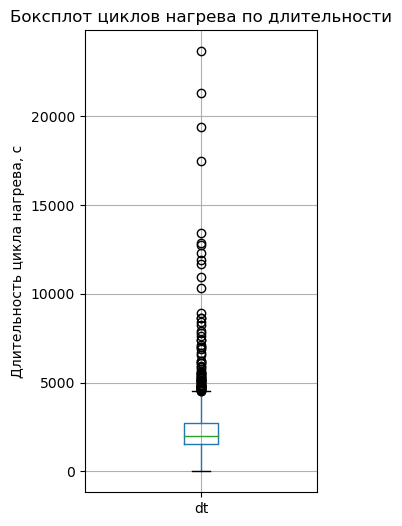

```python
# Рассмотрим подробнее 'dt'в области больших значений
box_plot=temp.boxplot(column='dt', grid= True, figsize=(3, 6));# Распределение значений
box_plot.set(xlabel='',ylabel='Длительность цикла нагрева, с',
             title='Боксплот циклов нагрева по длительности');
temp['dt'].describe()
```

```python
# Рассмотрим данные о самых продолжительных процессах
D = temp.loc[temp['dt']>20000].index.tolist()#
for i in D:
    display(data[4].loc[data[4]['key'] == i])
```

|  | key | Время замера | Температура |
| --- | --- | --- | --- |
| 9467 | 1689 | 2019-07-05 08:07:11 | 1583 |
| 9468 | 1689 | 2019-07-05 08:11:56 | 1591 |
| 9469 | 1689 | 2019-07-05 08:20:43 | 1597 |
| 9470 | 1689 | 2019-07-05 08:32:41 | 1600 |
| 9471 | 1689 | 2019-07-05 08:40:50 | 1602 |
| 9472 | 1689 | 2019-07-05 11:22:57 | 1608 |
| 9473 | 1689 | 2019-07-05 11:30:40 | 1526 |
| 9474 | 1689 | 2019-07-05 12:39:10 | 1559 |
| 9475 | 1689 | 2019-07-05 12:51:31 | 1575 |
| 9476 | 1689 | 2019-07-05 14:05:04 | 1626 |
| 9477 | 1689 | 2019-07-05 14:08:11 | 1587 |
| 9478 | 1689 | 2019-07-05 14:11:04 | 1604 |
| 9479 | 1689 | 2019-07-05 14:19:14 | 1600 |
| 9480 | 1689 | 2019-07-05 14:30:19 | 1603 |
| 9481 | 1689 | 2019-07-05 14:36:49 | 1589 |
| 9482 | 1689 | 2019-07-05 14:41:45 | 1606 |

|  | key | Время замера | Температура |
| --- | --- | --- | --- |
| 11825 | 2108 | 2019-07-27 10:41:03 | 1639 |
| 11826 | 2108 | 2019-07-27 11:07:14 | 1626 |
| 11827 | 2108 | 2019-07-27 11:13:27 | 1604 |
| 11828 | 2108 | 2019-07-27 11:15:35 | 1612 |
| 11829 | 2108 | 2019-07-27 11:19:16 | 1621 |
| 11830 | 2108 | 2019-07-27 11:23:02 | 1535 |
| 11831 | 2108 | 2019-07-27 13:39:22 | 1577 |
| 11832 | 2108 | 2019-07-27 13:45:09 | 1585 |
| 11833 | 2108 | 2019-07-27 13:49:26 | 1559 |
| 11834 | 2108 | 2019-07-27 14:01:13 | 1562 |
| 11835 | 2108 | 2019-07-27 15:10:40 | 1587 |
| 11836 | 2108 | 2019-07-27 15:17:49 | 1582 |
| 11837 | 2108 | 2019-07-27 15:21:39 | 1544 |
| 11838 | 2108 | 2019-07-27 15:32:25 | 1537 |
| 11839 | 2108 | 2019-07-27 16:22:44 | 1582 |
| 11840 | 2108 | 2019-07-27 16:32:07 | 1578 |
| 11841 | 2108 | 2019-07-27 16:36:34 | 1541 |

Вывод: Рассмотрев данные о продолжительных процессах приходим к выводу, что нет причин полагать, что это выбросы.

#### Температура

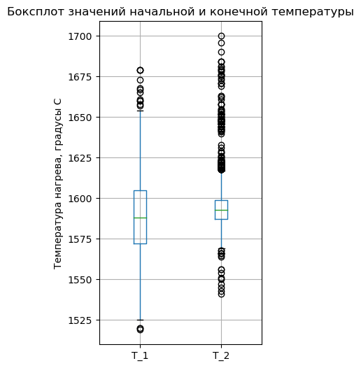

```python
# Проверим на налиие выбросов температуру
p = ['T_1', 'T_2']# Составим список объектов
box_plot=temp.boxplot(column=p, grid= True, figsize=(3, 6));# Распределение значений
box_plot.set(xlabel='',ylabel='Температура нагрева, градусы С',
             title='Боксплот значений начальной и конечной температуры');
```

Вывод: необходимо рассмотреть выбросы конечной температуры на общем df.

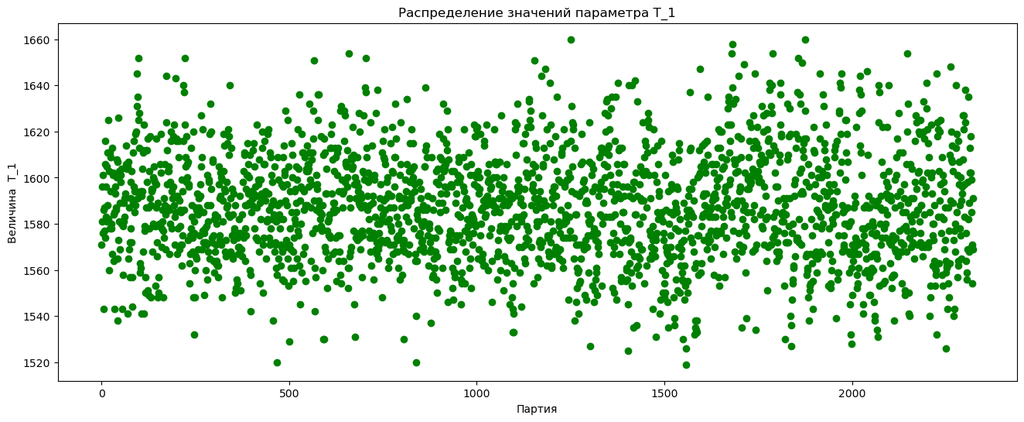

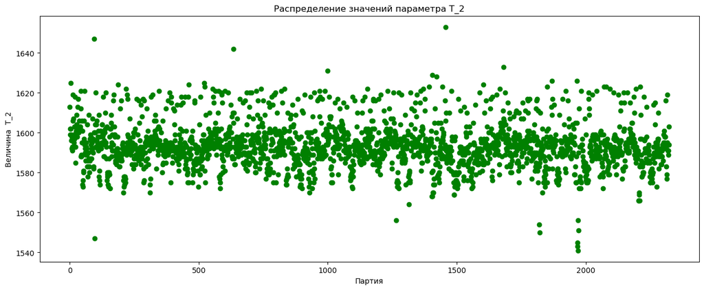

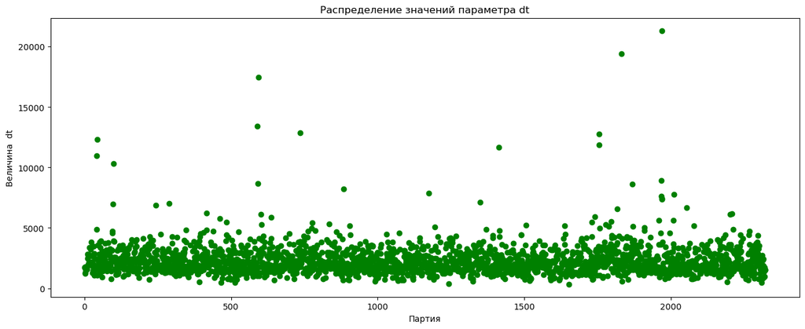

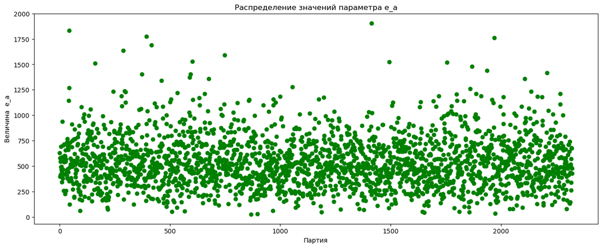

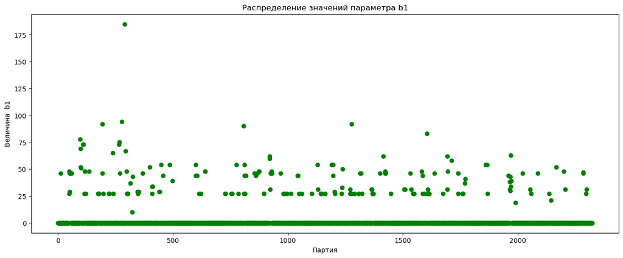

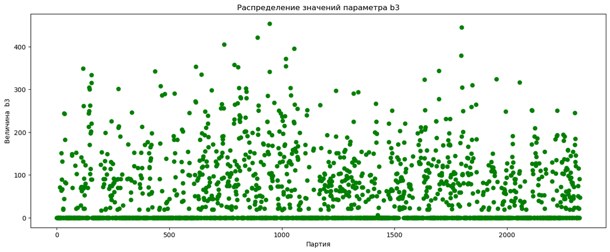

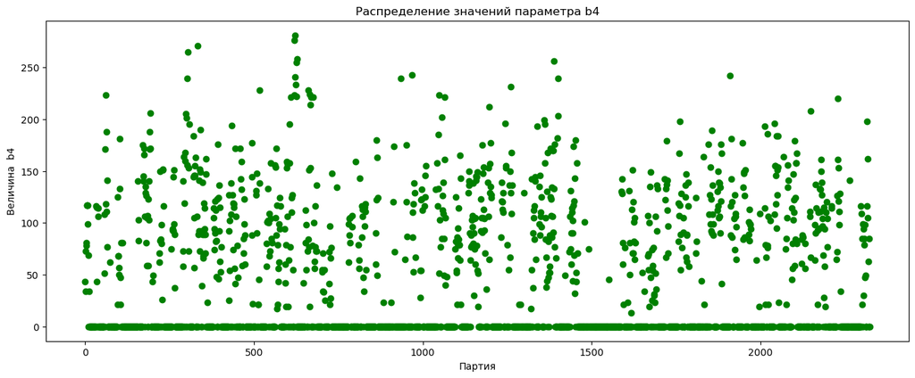

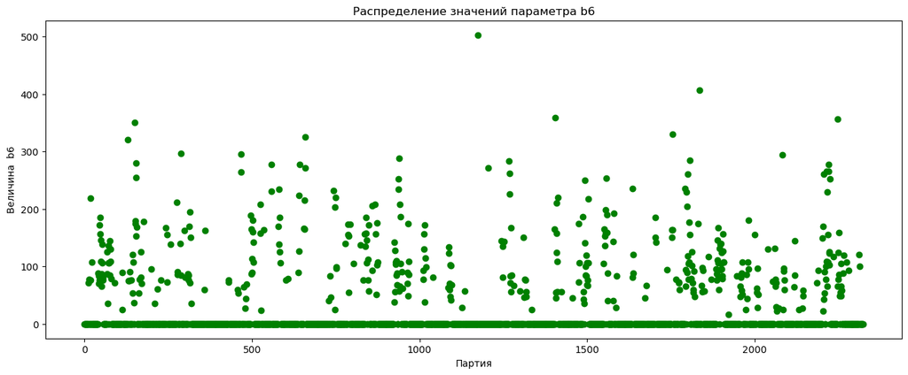

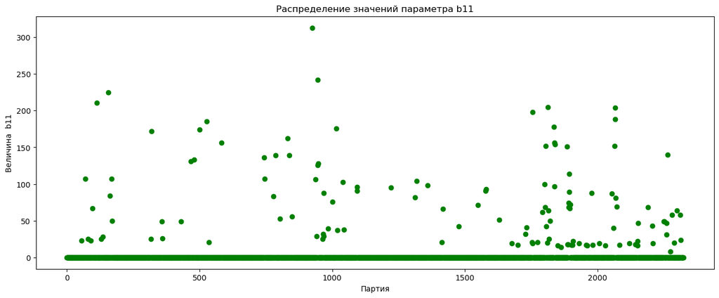

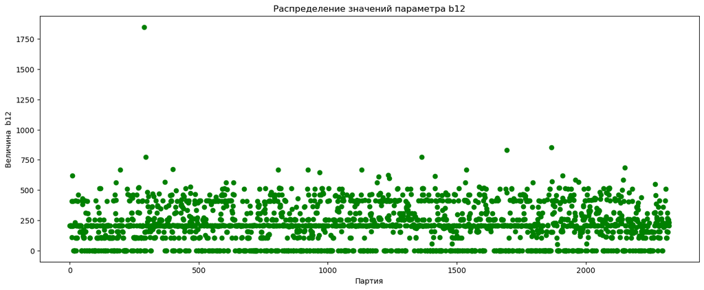

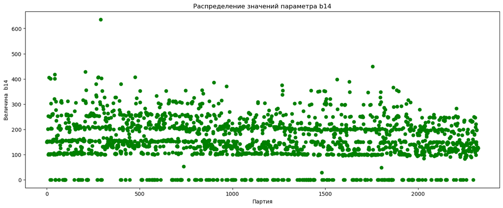

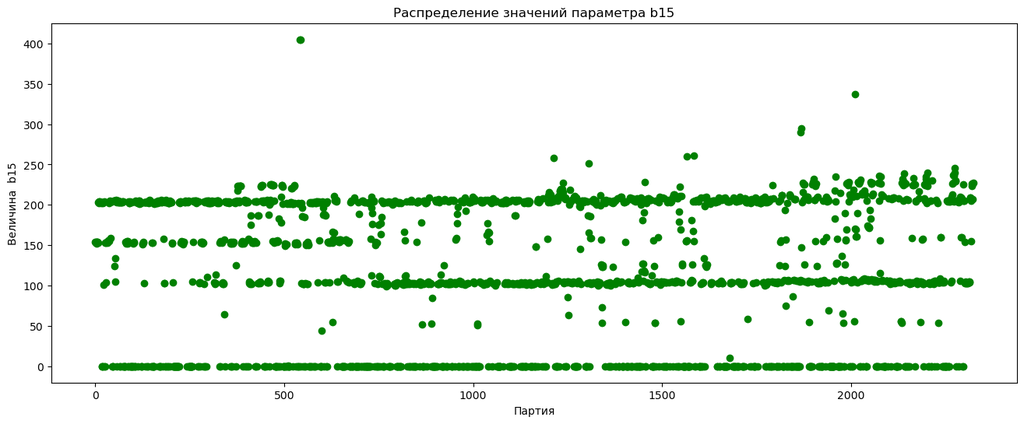

[5 more figures not shown]

```python
# Построим для каждого признака график распределения
def graph_distribution(i, df): # Зададим функцию построения графика распределения
    x = df.index.tolist() #  x - координаты точек
    y = df[i]#  y - координаты точек
    fig, ax = plt.subplots()
    ax.scatter(x, y, c = 'g' )    #  цвет точек
    ax.set_facecolor('w')     #  цвет области Axes
    ax.set_title(f"Распределение значений параметра {i}")     #  заголовок для Axes
    plt.xlabel("Партия")
    plt.ylabel(f"Величина  {i}")
    fig.set_figwidth(16)     #  ширина и
    fig.set_figheight(6)    #  высота "Figure"

    return plt.show()

for i in df.columns.tolist(): # Переберём все признаки df.
    graph_distribution(i, df)
```

Вывод:

Необычно высокие и низкие значения конечной температуры указывают на возможные нарушения технологии в данной партии. Удалим такие партии у которых значение `Т_2` больше 1635 (три партии) и меньше 1560 градусов (9 партий).

#### Удаление выброса по температуре

```python
df = df.loc[(df['T_2']>1560) & (df['T_2']<1635)]
```

#### Матрицу корреляции всех признаков в виде тепловой карты heatmap

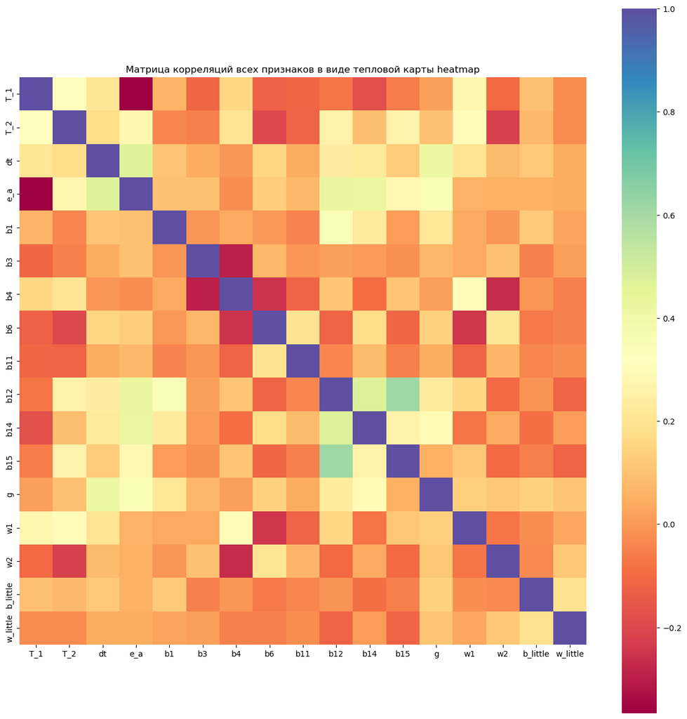

```python
# Построим матрицу корреляций всех признаков в виде тепловой карты heatmap.
plt.figure(figsize = (16,16))
sns.heatmap(df.corr(), annot = False, square=True, cmap= 'Spectral', fmt = '.1g')#, cbar=False
plt.title('Матрица корреляций всех признаков в виде тепловой карты heatmap');
```

Наибольшую корреляцию (около 0,5) наблюдаем в двух парах: сыпучие добавки `b12`--`b15` и `энергия`--`длительность`.

### Разделение данных на выборки

```python
# Проведём разделение данных на выборки
features = df.drop('T_2', axis=1)
target = df['T_2']
features_train, features_test, target_train, target_test = train_test_split(
    features, target, test_size=0.25, random_state=170723)
features_train.info()
```

```
<class 'pandas.core.frame.DataFrame'>
Int64Index: 1733 entries, 669 to 2083
Data columns (total 16 columns):
 #   Column    Non-Null Count  Dtype
---  ------    --------------  -----
 0   T_1       1733 non-null   uint16
 1   dt        1733 non-null   uint16
 2   e_а       1733 non-null   float32
 3   b1        1733 non-null   uint16
 4   b3        1733 non-null   uint16
 5   b4        1733 non-null   uint16
 6   b6        1733 non-null   uint16
 7   b11       1733 non-null   uint16
 8   b12       1733 non-null   uint16
 9   b14       1733 non-null   uint16
 10  b15       1733 non-null   uint16
 11  g         1733 non-null   uint8
 12  w1        1733 non-null   uint16
 13  w2        1733 non-null   uint16
 14  b_little  1733 non-null   uint16
 15  w_little  1733 non-null   uint16
dtypes: float32(1), uint16(14), uint8(1)
memory usage: 69.4 KB
```

Требование получить обучающую выборку не менее 1700 строк выполнено.

### Применение моделей

#### Функция случайного поиска

```python
def random_search(name, model, parameters, X, y):
    model_random = RandomizedSearchCV(model, parameters, n_iter=20, scoring='neg_mean_absolute_error', n_jobs=-1,
             cv=3, verbose=-1) # , verbose=0, n_jobs=-1 использовать все ЦП для обучения, по умолчанию 1, использовать 1 ЦП
    model_random = model_random.fit(X, y);
    # Лучший результат и гиперпараметры
    print('Модель -',name, '.  Лучшие показатели при случайном поиске')
    print('Гиперпараметры: '+str(model_random.best_params_))
    print('Результат: ',round(-model_random.best_score_, 2))
```

#### Функция поиска по сетке

```python
def grid_search(name, model, parameters, X, y):
    model_grid = GridSearchCV(model, param_grid=parameters, scoring='neg_mean_absolute_error',
            n_jobs=-1, cv=3, verbose=-1)
    # n_jobs=-1 использовать все ЦП для обучения, по умолчанию 1, использовать 1 ЦП
    model_grid = model_grid.fit(X, y);
    res = round(-model_grid.best_score_, 2)
    # Лучший результат и гиперпараметры
    print('Модель -',name, '.  Лучшие показатели при поиске по сетке')
    print('Гиперпараметры: '+str(model_grid.best_params_))
    print('Результат: ', res)

    return name, res
```

#### Модель - `RandomForestRegressor`

```python
# Лес
# Запуск случайного поиска
name = 'RandomForestRegressor()'
rm = RandomForestRegressor()
r_space={'max_depth':list(np.arange(1, 10, step=1)) + [None], # максимальный уровень (глубину) каждого дерева
         #в модели случайного леса
              'n_estimators':np.arange(1, 16, step=1), # Количество деревьев решений в лесу
              'max_features':randint(1, 16), # Максимальное количество признаков, которое модели случайного леса
         #разрешается опробовать при каждом разбиении. По умолчанию в Scikit-Learn это значение устанавливается
         #равным квадратному корню из общего числа переменных в наборе данных.
              'min_samples_leaf':randint(1,6), # Минимальное количество образцов, необходимое для нахождения
         #в листовом узле каждого дерева. В Scikit-Learn значение по умолчанию равно 1.
              'min_samples_split':np.arange(1, 6, step=1) # Минимальное количество образцов, необходимое для
         #разбиения внутреннего узла каждого дерева. В Scikit-Learn значение по умолчанию равно 2.
          }

random_search(name, rm, r_space, features_train, target_train)
```

```
Модель - RandomForestRegressor() .  Лучшие показатели при случайном поиске
Гиперпараметры: {'max_depth': 7, 'max_features': 13, 'min_samples_leaf': 1, 'min_samples_split': 4, 'n_estimators': 14}
Результат:  6.5
```

```python
# Лес
# Запуск поиска по сетке
name = 'RandomForestRegressor()'
gm = RandomForestRegressor()
g_space={'max_depth': [8, 9, 10], # максимальный уровень (глубину) каждого дерева в модели случайного леса
              'n_estimators':np.arange(15, 18, step=1), # Количество деревьев решений в лесу
              'max_features':[ 14, 15, 16], # Максимальное количество признаков, которое модели случайного леса
         #разрешается опробовать при каждом разбиении. По умолчанию в Scikit-Learn это значение
         #устанавливается равным квадратному корню из общего числа переменных в наборе данных.
              'min_samples_leaf':[2, 3, 4], # Минимальное количество образцов, необходимое для нахождения
         #  в листовом узле каждого дерева. В Scikit-Learn значение по умолчанию равно 1.
              'min_samples_split':[1, 2, 3] #np.arange(1, 2, step=1) Минимальное количество образцов, необходимое
         #для разбиения внутреннего узла каждого дерева. В Scikit-Learn значение по умолчанию равно 2.
          }

model_rf = grid_search(name, gm, g_space, features_train, target_train) # Лучший результат модели
print(model_rf)
```

```
Модель - RandomForestRegressor() .  Лучшие показатели при поиске по сетке
Гиперпараметры: {'max_depth': 8, 'max_features': 14, 'min_samples_leaf': 2, 'min_samples_split': 3, 'n_estimators': 15}
Результат:  6.41
('RandomForestRegressor()', 6.41)
```

```python
params_rf = {'max_depth': 9, 'max_features': 16, 'min_samples_leaf': 4, 'min_samples_split': 2, 'n_estimators': 17}
```

#### Модель `DecisionTreeRegressor`

```python
# Дерево
# Запуск случайного поиска
name = 'DecisionTreeRegressor()'
rm = DecisionTreeRegressor()
r_space={'max_depth':list(np.arange(1, 60, step=1)),# + [None], # максимальный уровень (глубину) каждого дерева
              'max_features':randint(1,16), # Максимальное количество признаков, которое модели разрешается
         # опробовать при каждом разбиении. По умолчанию в Scikit-Learn это значение устанавливается равным
         #квадратному корню из общего числа переменных в наборе данных.
              'min_samples_leaf':randint(1,10), # Минимальное количество образцов, необходимое для нахождения
         # в листовом узле каждого дерева. В Scikit-Learn значение по умолчанию равно 1.
              'min_samples_split':np.arange(1, 10, step=1) # Минимальное количество образцов, необходимое для
         # разбиения внутреннего узла каждого дерева. В Scikit-Learn значение по умолчанию равно 2.
          }

random_search(name, rm, r_space, features_train, target_train)
```

```
Модель - DecisionTreeRegressor() .  Лучшие показатели при случайном поиске
Гиперпараметры: {'max_depth': 5, 'max_features': 12, 'min_samples_leaf': 9, 'min_samples_split': 2}
Результат:  7.09
```

```python
# Дерево
# Запуск поиска по сетке
name = 'DecisionTreeRegressor()'
gm = DecisionTreeRegressor()
g_space={'max_depth': [3, 4, 5, 6] + [None], # максимальный уровень (глубину) каждого дерева
              'max_features':[ 8, 9, 10, 11], # Максимальное количество признаков,
         # которое модели разрешается опробовать при каждом разбиении.
         # По умолчанию в Scikit-Learn это значение устанавливается равным квадратному корню
         # из общего числа переменных в наборе данных.
              'min_samples_leaf':np.arange(3, 6, step=1), # Минимальное количество образцов,
         # необходимое для нахождения в листовом узле каждого дерева. В Scikit-Learn значение по умолчанию равно 1.
              'min_samples_split':np.arange(7, 10, step=1) # Минимальное количество образцов,
         # необходимое для разбиения внутреннего узла каждого дерева. В Scikit-Learn значение по умолчанию равно 2.
          }

model_dt = grid_search(name, gm, g_space, features_train, target_train) # Лучший результат модели 'RandomForestRegressor()'
print(model_dt)
```

```
Модель - DecisionTreeRegressor() .  Лучшие показатели при поиске по сетке
Гиперпараметры: {'max_depth': 5, 'max_features': 9, 'min_samples_leaf': 4, 'min_samples_split': 7}
Результат:  6.99
('DecisionTreeRegressor()', 6.99)
```

#### Модель `LinearRegression`

```python
# Линейная регрессия
def Mean_score_mini(model, features_train, target_train):
    scores = []
    sample_size = int(len(target)/3)# зададим размер блока, если их всего три
    valid_indexes, train_indexes = [], []

    for i in range(0, int(len(target)), sample_size):
        valid_indexes = target.index[i:i+sample_size]# < массив из индексов для валидационного блока >
        train_indexes = [x for x in target.index if x not in valid_indexes]# < массив из индексов
        # для обучающей выборки >
        features_train, target_train = features.loc[train_indexes, :], target.loc[train_indexes]
        features_valid, target_valid = features.loc[valid_indexes, :], target.loc[valid_indexes]

        mean_model = model.fit(features_train, target_train)
        predicted_valid = mean_model.predict(features_valid)
        score = mean_absolute_error(target_valid, predicted_valid)# Оценим качество модели
        scores.append(score)

    return  np.mean(scores), mean_model # Посчитаем среднее качество модели по итогам  кросс-валидации

lin_reg = LinearRegression() # инициализируем модель LinearRegression
mean_score, lin_reg = Mean_score_mini(lin_reg, features, target)# Запустим модель посредством
# функции кросс-валидации
model_lr = 'LinearRegression', round(mean_score, 2)
print(model_lr)
```

```
('LinearRegression', 8.39)
```

#### Модель `CatBoost`

```python
m_catb = CatBoostRegressor()

X_train,y_train = features_train, target_train
```

grid = {'learning_rate': [0.03, 0.1], 'depth': [2, 3], 'l2_leaf_reg': [0.1, 0.3]}

grid_search_result = m_catb.grid_search(grid, X=X_train, y=y_train, plot=True, verbose=0);

```python
X_train,y_train = features_train, target_train
iterations=10
depth=2
learning_rate=0.1
l2_leaf_reg = 0.1

m_catb = cb.CatBoostRegressor(iterations=iterations, depth=depth,
                              learning_rate=learning_rate, l2_leaf_reg=l2_leaf_reg,
                              loss_function='MAE', logging_level=None, verbose=0)
m_catb.fit(X_train,y_train, verbose=0)
cv = RepeatedStratifiedKFold(n_splits=3, n_repeats=3, random_state=170723)
scores_catb = np.mean(-cross_val_score(m_catb, X_train,y_train, scoring='neg_mean_absolute_error',
                              cv=cv, n_jobs=-1, error_score='raise', verbose=0));
```

```python
name = 'CatBoostRegressor()'
model_cb = 'CatBoostRegressor()', scores_catb
# Лучший результат и гиперпараметры
print('Модель -',name, '.  Лучшие показатели')
print('Гиперпараметры: ', 'iterations=', iterations, ',    depth=', depth,
      ',    learning_rate=', learning_rate, ',    l2_leaf_reg=', l2_leaf_reg)
print('Результат: ',m_catb.best_score_)
print(model_cb);
```

```
Модель - CatBoostRegressor() .  Лучшие показатели
Гиперпараметры:  iterations= 10 ,    depth= 2 ,    learning_rate= 0.1 ,    l2_leaf_reg= 0.1
Результат:  {'learn': {'MAE': 7.2103147379680665}}
('CatBoostRegressor()', 7.270889749764649)
```

```python
params_cb = { 'iterations': 100 ,    'depth': 2 ,    'learning_rate': 0.1,  'l2_leaf_reg': 0.1,
             'loss_function':'MAE', 'logging_level': None}
```

С моделью CatBoostRegressor() возможно получить лучшие чем у остальных моделей метрики по MAE, но при последующем тестировании модель показыват не высокие значения по МАЕ и r2_score.

#### Модель `LGBMRegressor`

```python
# LGBMRegressor
# Запуск случайного поиска
name = 'lgb.LGBMRegressor()'
rm = lgb.LGBMRegressor()# verbose=0
r_space = {'num_leaves': np.arange(6, 8, step=1),
          'n_estimators': np.arange(90, 110, step=1),# 'num_iterations'
          'max_depth': np.arange(2, 4, step=1),
          'lambda_l2':[  8, 9, 10],
          'learning_rate':[0.1],
          'bagging_fraction':np.arange(0.1, 0.3, step=0.1),
          'subsample':[1],
          'reg_lambda':[0],
          'verbose' : [-1]
         }

random_search(name, rm, r_space, features_train, target_train);
```

```
Модель - lgb.LGBMRegressor() .  Лучшие показатели при случайном поиске
Гиперпараметры: {'verbose': -1, 'subsample': 1, 'reg_lambda': 0, 'num_leaves': 7, 'n_estimators': 94, 'max_depth': 3, 'learning_rate': 0.1, 'lambda_l2': 8, 'bagging_fraction': 0.2}
Результат:  6.29
```

```python
# LGBMRegressor
# Запуск поиска по сетке
name = 'lgb.LGBMRegressor()'
gm = lgb.LGBMRegressor()
g_space={'num_leaves': np.arange(6, 8, step=1),
          'n_estimators': np.arange(97, 99, step=1),#'num_iterations'
          'max_depth': [2, 3, 4],
          'lambda_l2':[ 8, 9, 10],
          'learning_rate':[0.1],
          'bagging_fraction':[0.1, 0.2],
          #'subsample':[1],
          #'reg_lambda':[0],
          'verbose' : [-1]
        }

model_lgb = grid_search(name, gm, g_space, features_train, target_train); # Поиск гиперпараметров по сетке
# с помощью модели GridSearchCV
print(model_lgb);
```

```
Модель - lgb.LGBMRegressor() .  Лучшие показатели при поиске по сетке
Гиперпараметры: {'bagging_fraction': 0.1, 'lambda_l2': 9, 'learning_rate': 0.1, 'max_depth': 3, 'n_estimators': 98, 'num_leaves': 7, 'verbose': -1}
Результат:  6.26
('lgb.LGBMRegressor()', 6.26)
```

```python
params_lgb = {'bagging_fraction': 0.1, 'lambda_l2': 9, 'learning_rate': 0.1, 'max_depth': 3,
              'n_estimators': 98,'num_leaves': 7, 'reg_lambda': 0, 'subsample': 1, 'verbose': -1}
```

### Выбор лучшей модели

[figure not shown]

```python
M = pd.DataFrame([model_dt, model_lr, model_rf, model_cb, model_lgb],
                 columns=['name', 'MAE'])

fig, ax = plt.subplots(figsize=(14,8), dpi= 80)
ax.vlines(x=M['name'], ymin=0, ymax=M.MAE, color='firebrick', alpha=0.7, linewidth=2)
ax.scatter(x=M['name'], y=M.MAE, s=100, color='firebrick', alpha=0.7)

ax.set_title('Точность прогноза у различных моделей', fontdict={'size':22})
ax.set_ylabel('MAE, градусы', fontsize=16)
ax.set_xlabel('Модели', fontsize=16)
ax.set_xticks(M['name'])
ax.set_xticklabels(M.name, rotation=0, fontdict={'horizontalalignment': 'center', 'size':12})
ax.set_ylim(5.5, 9)

for row in M.itertuples():
    ax.text(row.Index, row.MAE+.05, s=round(row.MAE, 2), horizontalalignment= 'center',
            verticalalignment='bottom', fontsize=16)

plt.show()
```

```python
# Выбрали лучшую модель: LGBMRegressor

params = params_lgb
model = lgb.LGBMRegressor(**params, verbose_eval=False)
best_model = model.fit(features_train, target_train)
cv = RepeatedStratifiedKFold(n_splits=50, n_repeats=3, random_state=170723)
scores = cross_val_score(best_model, features_train, target_train,
                         scoring='neg_mean_absolute_error',
                         cv=cv, n_jobs=-1)#, verbose=False

print('Лучший результат: ', round(-np.mean(scores), 2))# Лучший результат
```

```
Лучший результат:  6.24
```

### Тестирование лучшей модели

Лучшая модель: `LGBMRegressor`.

Лучшие гиперпараметры :

> { 'bagging_fraction': 0.1,\ 'lambda_l2': 9, \ 'learning_rate': 0.1, \ 'max_depth': 3,\ 'n_estimators': 98,\ 'num_leaves': 7, \ 'reg_lambda': 0, \ 'subsample': 1, \ 'verbose': -1 }
1. Сделаем данной моделью предсказание методом `predict` на тестовой выборке;
2. Рассчитаем итоговое `МАЕ`;
3. Создадим константную модель `DummyRegressor`;
4. Рассчитаем метрику `r2` на тестовой выборке для лучшей модели и константной
5. Интерпретируем метрику `r2`.

```python
lm_dummy_mean = DummyRegressor(strategy = 'mean' ).fit(features_train, target_train)

y_predict = best_model.predict(features_test)
y_predict_dummy_mean = lm_dummy_mean.predict(features_test)
print()
print ( "Константная модель 'DummyRegressor', MAE: {:.2f}" .
       format (mean_absolute_error(target_test, y_predict_dummy_mean)))
print()
print ( 'Лучшая модель "LGBMRegressor", MAE:  {:.2f}' .
       format (mean_absolute_error(target_test, y_predict)))
print()
print ( "r2_score (Константная модель 'DummyRegressor'): {:.2f}" .
       format (r2_score(target_test, y_predict_dummy_mean)))
print()
print ( "r2_score (Лучшая модель 'LGBMRegressor'): {:.2f}" .
       format (r2_score(target_test, y_predict)))
```

```
Константная модель 'DummyRegressor', MAE: 8.16

Лучшая модель "LGBMRegressor", MAE:  6.40

r2_score (Константная модель 'DummyRegressor'): -0.00

r2_score (Лучшая модель 'LGBMRegressor'): 0.40
```

`r2_score` равен 0,40, что указывает на то, что 40% дисперсии температуры `Т_2` можно объяснить с помощью нашей модели.

### Исследование важности признаков

Исследование важности признаков у лучшей модели.

```
[LightGBM] [Warning] Unknown parameter: verbose_eval
[LightGBM] [Warning] bagging_fraction is set=0.1, subsample=1 will be ignored. Current value: bagging_fraction=0.1
[LightGBM] [Warning] lambda_l2 is set=9, reg_lambda=0 will be ignored. Current value: lambda_l2=9
```

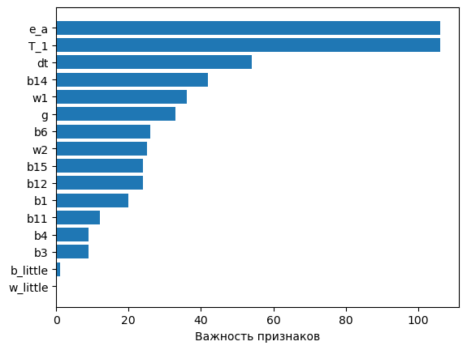

```python
pd.options.mode.chained_assignment = None#Подавим предупреждение которое появляется,
# когда pandas сталкивается с чем-то, что называется цепным назначением
X = features
y = target
model.fit(X, y)
sorted_idx = np.argsort(model.feature_importances_)
plt.barh(np.array(X.columns.tolist())[sorted_idx], best_model.feature_importances_[sorted_idx])
plt.xlabel("Важность признаков");
```

## Заключение

Поставленная цель достигнута - применив машинное обучение, мы можем прогнозировать температуру Т_2 на основе доступной информации снимаемой со штатных регистраторов. С помощью градиентного бустинга удалось на тестовых данных добиться погрешности в пределах 6.40, что соответствует требованию Заказчика (не хуже 6.8).

Наибольший эффект в повышении точности прогноза достигнут был в результате обработки данных. А именно ручного удаления выбросов, таких как отрицательная мощность и низкая температура и применения отдельно для обучающей выборки машинного алгоритма удаления аномалий.

С целью уменьшения вычислительной нагрузки при эксплуатации нашей модели из состава входных данных были исключены:

- Температура, дата/время и вес порций добавок внутри партий,
- Абсолютные значения Дата/время и номера партий,
- Реактивная мощность,
- редковстречающиеся параметры b10, b2, b5, b7, b8, b9, b13 объединены в параметр b_little,
- редковстречающиеся параметры w3, w4, w6, w7, w8, w9 объединены в параметр w_little.

Для получения наилучших результатов при подборе гиперпараметров использовался как случайный поиск, так и поиск по сетке. Сначала для разведки применялся случайный поиск, так как он быстрее. Затем, используя полученные гиперпараметры, выполнялся сеточный поиск в узком диапазоне значений.

## Отчёт

Цель данного проекта: снизить затраты на электричество, обслуживание и ремонты. Задача проекта: создать модель которая позволит прогнозировать конечную температуру продукта с точностью не хуже 6,8 градуса.

Для решения данной задачи нам были предоставлены данные регистраторов имеющиеся в распоряжении у Заказчика, а так же была организована встреча на которой представитель Заказчика отвечал на вопросы касающиеся технологи производства.

### Сравнение решения и плана

Работа была выполнена в соответствии с первоначальным планом.

1. Получить ответы Заказчика на уточняющие вопросы. --- Вопросы были заданы, а ответы получены.
2. Составить список параметров необходимых для обучения модели. --- Список параметров был составлен, но в последствии он был дополнен. Изначально планировалось объединить все сыпучие добавки в один параметр Bulk (просуммировать по партиям все 15 добавок), а все добавки проволки агрегировать в Wire. Но такой подход не позволил достичь желаемой точности. В итоге выполнили объединение только редковстречающихся семи параметров b10, b2, b5, b7, b8, b9, b13 в параметр b_little и шести параметров w3, w4, w6, w7, w8, w9 в параметр w_little. В первоначальный список параметров входила и Реактивная энергия, но после анализа корреляций она была исключена. Так же была предпринята попытка ввести внеплановый параметр равный количеству циклов для каждой партии, но к ощутимому росту точности это не привело и от такого параметра отказались.

3.Определиться, что будем считать выбросами. Удалить выбросы. --- Определились, что будем считать выбросами:

- Реактивную мощность меньше 0 из 'arc' - удалили данные партии;
- Данные с нарушением хронологии - удалили такие партии;
- Температуру T_1 и T_2 меньшую 1500 из 'temp' - удалили такие партии.
1. Агрегировать имеющиеся данные по партиям, рассчитать новые параметры. (В таблице 'arc', создать три новых параметра Е_а, Е_р и dt , соответствующих Активной и Реактивной энергии и длительности партии. В таблице 'temp' создать два новых параметра T_1 и T_2, соответствующие начальной и конечной температуре партии. Удалить неинформативные партии у которых отсутствует начальная или конечная температура.) --- Всё это было реализовано по плану и в результате датасет temp лишился 20% т. к. начиная со строки 13926 (партия 2500) в данных для всех партий присутствовала только одна начальная температура. Следовательно данные партий с 2501 по 3241 были удалены.
2. Объединить данные по методу INNER, оставив только те партии ('key') которые присутствуют во всех объединяемых датасетах. --- План был осуществлён, объединённый датасет стал состоять из 2324 строк и 17 параметров (T_1', 'T_2', 'dt', 'e_а', 'b1', 'b3', 'b4', 'b6', 'b11', 'b12', 'b14', 'b15', 'g', 'w1', 'w2', 'b_little', 'w_little').
3. Вывести графики распределения всех признаков объединённого датасета. --- Выведены 17 графиков.
4. Построить матрицу корреляций всех признаков в виде тепловой карты heatmap. При использовании линейной регрессии, удалить любой из признаков в каждой паре высококоррелирующих признаков (напр. >0.9). --- Построена.
5. Выполнить кросс-валидацию для 75% данных, на тестирование оставляем 25 % данных, выводим размеры полученных выборок. --- Выполнено в соответствии с планом.
6. Обучить не менее 2-х моделей с кросс-валидацией, подбор не менее 2-х наборов гиперпараметров с GridSearchCV или RandomizedSearchCV хотя бы у одной модели (к примеру, перебирать как `max_depth`, так и `min_samples_leaf`). --- Были обучены с кросс-валидацией 5 моделей. Для получения наилучших результатов при подборе гиперпараметров использовался как случайный поиск RandomizedSearchCV, так и поиск по сетке GridSearchCV. Сначала для разведки применялся случайный поиск, так как он быстрее. Затем, используя полученные гиперпараметры, выполнялся сеточный поиск в узком диапазоне значений.
7. Выбрать лучшую модель по .best*score*. Для лучшей модели рассчитаем метрику r2 на тестовой выборке и интерпретировать её. --- Лучшая модель LGBMRegressor с МАЕ = 6.4 на тестовой выборке. "r2_score" равен 0.4, что указывает на то, что 40% дисперсии температуры Т_2 можно объяснить с помощью нашей модели.
8. Тестировать лучшую модель, провести её сравнение с константной моделью DummyRegressor (обучение на трейне, предсказание на тестовой выборке). ---

Константная модель 'DummyRegressor', MAE: 8.16

Лучшая модель "LGBMRegressor", MAE: 6.40

r2_score (Константная модель 'DummyRegressor'): -0.00

r2_score (Лучшая модель 'LGBMRegressor'): 0.40

### Описание трудностей проекта и как они были решены

Трудность выбора была связана с моделью CatBoostRegressor. С данной моделью возможно получить лучшие чем у остальных моделей метрики по MAE, но при последующем тестировании модель показыват не высокие значения по МАЕ и r2_score.

### Описание ключевых шагов

Ключевые шаги решений:

- Выбор в качестве параметра Активной энергии;
- Агрегирование данных по партиям;
- Объединение данных по методу INNER с удалением партий которые отсутствуют во всех объединяемых массивах;
- Объединение редковстречающихся параметров b10, b2, b5, b7, b8, b9, b13 в параметр b_little;
- Объединение редковстречающихся параметров w3, w4, w6, w7, w8, w9 в параметр w_little;
- Обучение моделей с кросс-валидацией и подбором гиперпараметров;
- Исследование важности признаков. Повлекло корректировку в наборе признаков.

### Все признаки, которые использовались для обучения Итоговой модели и их предобработка

'T_2' - Конечная температура партии (целевой признак). Выбрана из 'data_temp_new.csv'. Предок - 'Температура' с максимальным 'Время замера' при группировке по 'key'. Удаление партий при наличие пропусков либо значений выходящих за пределы диапазона от 1560 до 1635 градусов С.

'T_1' - Начальная температура партии. Выбрана из 'data_temp_new.csv'. Предок - 'Температура' с минимальным 'Время замера' при группировке по 'key'. Удаление партии при наличие пропусков либо значений менее 1500.

'dt' - Продолжительность партии. Выбрана из 'data_temp_new.csv'. Предки - 'Время замера'максимальное и 'Время замера'минимальное при группировке по 'key'. Рассчитано как разность 'Время замера'максимальное и 'Время замера'минимальное при группировке по 'key'. Удаление партии при наличие пропусков либо нарушения хронологии.

'e_а' - Активная эл. энергия израсходованная на партию. Выбрана из 'data_arc_new.csv'. Предки 'Конец нагрева дугой', 'Начало нагрева дугой' и 'Активная мощность'. Рассчитано как сумма при группировке по 'key' произведения разности ('Конец нагрева дугой' и 'Начало нагрева дугой') и 'Активная мощность'. Удаление партии при наличие пропусков либо нарушения хронологии. Удаление выброса с большой энергией.

'b1' - Масса сыпучей добавки Bulk 1. Выбрана из 'data_bulk_new.csv'. Предок - 'Bulk 1' Рассчитано как сумма при группировке по 'key'. Удаление партии при наличии нарушений хронологии в 'data_bulk_time_new.csv'.

'b3' - Масса сыпучей добавки Bulk 3. Выбрана из 'data_bulk_new.csv'. Предок - 'Bulk 3' Рассчитано как сумма при группировке по 'key'. Удаление партии при наличии нарушений хронологии в 'data_bulk_time_new.csv'.

'b4' - Масса сыпучей добавки Bulk 4. Выбрана из 'data_bulk_new.csv'. Предок - 'Bulk 4' Рассчитано как сумма при группировке по 'key'. Удаление партии при наличии нарушений хронологии в 'data_bulk_time_new.csv'.

'b6' - Масса сыпучей добавки Bulk 6. Выбрана из 'data_bulk_new.csv'. Предок - 'Bulk 6' Рассчитано как сумма при группировке по 'key'. Удаление партии при наличии нарушений хронологии в 'data_bulk_time_new.csv'.

'b11' - Масса сыпучей добавки Bulk 11. Выбрана из 'data_bulk_new.csv'. Предок - 'Bulk 11' Рассчитано как сумма при группировке по 'key'. Удаление партии при наличии нарушений хронологии в 'data_bulk_time_new.csv'.

'b12' - Масса сыпучей добавки Bulk 12. Выбрана из 'data_bulk_new.csv'. Предок - 'Bulk 12' Рассчитано как сумма при группировке по 'key'. Удаление партии при наличии нарушений хронологии в 'data_bulk_time_new.csv'.

'b14' - Масса сыпучей добавки Bulk 14. Выбрана из 'data_bulk_new.csv'. Предок - 'Bulk 14' Рассчитано как сумма при группировке по 'key'. Удаление партии при наличии нарушений хронологии в 'data_bulk_time_new.csv'.

'b15' - Масса сыпучей добавки Bulk 15. Выбрана из 'data_bulk_new.csv'. Предок - 'Bulk 15' Рассчитано как сумма при группировке по 'key'. Удаление партии при наличии нарушений хронологии в 'data_bulk_time_new.csv'.

'g' - Объём газа. Выбрана из 'data_gas_new.csv'. Предок - 'Газ 1' Удаление партии при наличии нарушения монотонности в 'key'.

'w1' - Масса проволочной добавки Wire 1. Выбрана из 'data_wire_new.csv', . Предок - 'Wire 1' Рассчитано как сумма при группировке по 'key'. Удаление партии при наличии нарушений хронологии в 'data_wire_time_new.csv'.

'w2' - Масса проволочной добавки Wire 2. Выбрана из 'data_wire_new.csv', . Предок - 'Wire 2' Рассчитано как сумма при группировке по 'key'. Удаление партии при наличии нарушений хронологии в 'data_wire_time_new.csv'.

'b_little' - Масса редковстречающихся сыпучих добавок Bulk. Выбрана из 'data_bulk_new.csv'. Предки - Bulk 2, Bulk 5, Bulk 7, Bulk 8, Bulk 9, Bulk 10, Bulk 13. Рассчитано как сумма при группировке по 'key'. Удаление партии при наличии нарушений хронологии в 'data_bulk_time_new.csv'.

'w_little' - Масса редковстречающихся проволочных добавок Wire. Выбрана из 'data_wire_new.csv'. Предки - Wire 3, Wire 4, Wire 6, Wire 7, Wire 8, Wire 9. Рассчитано как сумма при группировке по 'key'. Удаление партии при наличии нарушений хронологии в 'data_wire_time_new.csv'.

### Полное описание Итоговой модели и итоговая метрика на тестовой выборке

Выбрали лучшую модель: LGBMRegressor

[output not shown]

model = lgb.LGBMRegressor(**params)

best_model = model.fit(features_train, target_train)

cv = RepeatedStratifiedKFold(n_splits=50, --- количество разбиений учебной выборки

```
n_repeats=3, --- количество повторов процесса перекрестной проверки

random_state=170723 --- параметр фиксирующий воспроизводимость

)
```

scores = cross_val_score(best_model, features_train, target_train,

```
scoring='neg_mean_absolute_error', --- метрика средней абсолютной погрешности

cv=cv, n_jobs=-1 --- используются все доступные вычислительные мощности

)
```

### Перспектива

Что нужно для дальнейшего совешенствования решения поставленной цели.

1. Для оценки корректности измерений температуры выяснить где и как производится измерение температуры (на поверхности ковша, в объёме расплава, контактными термопарами, по ИК излучению с поверхности расплава или оболочки ковша и т.д.).
2. Заказчик в ТЗ указал, что масса расплава в ковше всегда 100 тонн. Как контролируется масса? Сложно представить, что эта величина всегда будет стабильной. А изменение массы на 1% равносильно изменению энергии на -1% и вызовет соответствующую ошибку в определении конечной температуры.
3. Как происходит контроль состава расплава? Дистанционно или путём отбора пробы, с потерей тепла или без? Была выполнена попытка ввести параметр - количество циклов нагрева за партию, но значимого результата она не принесла.
4. Какое время ковш находится порожним?
5. Какие уставки (ограничения) установлены по электрической мощности или току и напряжению? Зная эти уставки можно эффективно удалять выбросы по мощности.
6. Что скрывается за обозначениями добавок? Какие сущности, одинаковая ли у них начальная температура? Чем отличается от остальных параметр b10, добавляют его в не самых малых количествах, а воздействие его на систему меньше чем у остальных?